# 1.5.Linear.Models.Complexity.Metrics

Kevin Bruce

Last compiled on 06 January, 2021

#Load Packages/Data

# Overview of each variable

Site = Random effect to account for difference between ppqs at a single site (not found in any of top models)

Region = Ultimately, this is to check and see whether different levels of wave energy/etc. found in select regions plays a role on the complexity around the atoll

Hum_Dist = Categorical human disturbance variable, “Very Low” is part of the baseline

sqrt.hdist.cont= Continuous human disturbance gradient value square root transformed

# Model Selection

AICc will be used anytime n/k < 40. (n = sample size, k = # of parameters in model). - Therefore, for models with all DEM’s involved, AIC will be used - If we choose to breakdown models into indvidual DEM scales (n = 127), anything with more than K=3 will require AICc (Burnham & Anderson, 2004 –> Page 270 of document)

# Data Selection

- All data will be modelled for 1cm DEM intially, with further breakdowns done for additional DEM’s at a later date

# Computing mean and standard dev

## 1. VRM

### A. Investigating categorical Hum_Dist vs continuous square root transformed Hum_dist

```r
#Models looking at disturbance gradient and if interaction between year&disturbance fit better
vrm1 <- lm(vrm ~ year + hum_dist, data = mpq.1) #Hum_Dist = Categorical
vrm2 <- lm(vrm ~ year + sqrt.hdist.cont, data = mpq.1)
vrm3 <- lm(vrm ~ year * hum_dist, data = mpq.1)
vrm4 <- lm(vrm~year*sqrt.hdist.cont, data = mpq.1)

AIC(vrm1, vrm2,vrm3,vrm4) #Top model = vrm4
```

```
##      df       AIC
## vrm1  8 -771.6774
## vrm2  7 -779.9999
## vrm3 16 -770.4245
## vrm4 11 -787.0993
```

```r
summary(vrm1)
```

```
##
## Call:
## lm(formula = vrm ~ year + hum_dist, data = mpq.1)
##
## Residuals:
##       Min        1Q    Median        3Q       Max
## -0.021162 -0.006914 -0.001670  0.006821  0.027453
##
## Coefficients:
##                    Estimate Std. Error t value Pr(>|t|)
## (Intercept)        0.086450   0.002672  32.358  < 2e-16 ***
## year2016a         -0.022455   0.003297  -6.811 4.11e-10 ***
## year2016b         -0.026383   0.003107  -8.492 6.39e-14 ***
## year2017          -0.025766   0.003008  -8.565 4.32e-14 ***
## year2019          -0.010176   0.003173  -3.207  0.00172 **
## hum_distMedium    -0.014942   0.002501  -5.975 2.42e-08 ***
## hum_distVery High -0.023357   0.002493  -9.370 5.44e-16 ***
## ---
## Signif. codes:  0 '***' 0.001 '**' 0.01 '*' 0.05 '.' 0.1 ' ' 1
##
## Residual standard error: 0.0112 on 120 degrees of freedom
## Multiple R-squared:  0.6194, Adjusted R-squared:  0.6003
## F-statistic: 32.54 on 6 and 120 DF,  p-value: < 2.2e-16
```

```r
summary(vrm2)
```

```
##
## Call:
## lm(formula = vrm ~ year + sqrt.hdist.cont, data = mpq.1)
##
## Residuals:
##       Min        1Q    Median        3Q       Max
## -0.023459 -0.007685 -0.001115  0.006997  0.028622
##
## Coefficients:
##                   Estimate Std. Error t value Pr(>|t|)
## (Intercept)      8.528e-02  2.452e-03  34.785  < 2e-16 ***
## year2016a       -2.255e-02  3.201e-03  -7.043 1.24e-10 ***
## year2016b       -2.638e-02  3.018e-03  -8.742 1.57e-14 ***
## year2017        -2.561e-02  2.920e-03  -8.771 1.35e-14 ***
## year2019        -1.027e-02  3.082e-03  -3.333  0.00114 **
## sqrt.hdist.cont -3.167e-04  3.162e-05 -10.016  < 2e-16 ***
## ---
## Signif. codes:  0 '***' 0.001 '**' 0.01 '*' 0.05 '.' 0.1 ' ' 1
##
## Residual standard error: 0.01088 on 121 degrees of freedom
## Multiple R-squared:  0.6378, Adjusted R-squared:  0.6229
## F-statistic: 42.62 on 5 and 121 DF,  p-value: < 2.2e-16
```

```r
summary(vrm3)
```

```
##
## Call:
## lm(formula = vrm ~ year * hum_dist, data = mpq.1)
##
## Residuals:
##       Min        1Q    Median        3Q       Max
## -0.023104 -0.007613 -0.001262  0.006331  0.025587
##
## Coefficients:
##                              Estimate Std. Error t value Pr(>|t|)
## (Intercept)                  0.094044   0.003868  24.312  < 2e-16 ***
## year2016a                   -0.030716   0.006700  -4.585 1.19e-05 ***
## year2016b                   -0.032111   0.005470  -5.870 4.52e-08 ***
## year2017                    -0.036317   0.004994  -7.272 5.12e-11 ***
## year2019                    -0.024024   0.005909  -4.066 8.92e-05 ***
## hum_distMedium              -0.022504   0.005316  -4.233 4.74e-05 ***
## hum_distVery High           -0.037734   0.005316  -7.098 1.23e-10 ***
## year2016a:hum_distMedium     0.007669   0.008553   0.897  0.37184
## year2016b:hum_distMedium     0.006431   0.007518   0.855  0.39416
## year2017:hum_distMedium      0.009495   0.007179   1.323  0.18867
## year2019:hum_distMedium      0.014571   0.007843   1.858  0.06582 .
## year2016a:hum_distVery High  0.015838   0.008455   1.873  0.06364 .
## year2016b:hum_distVery High  0.010117   0.007518   1.346  0.18115
## year2017:hum_distVery High   0.022299   0.007179   3.106  0.00240 **
## year2019:hum_distVery High   0.024046   0.007843   3.066  0.00272 **
## ---
## Signif. codes:  0 '***' 0.001 '**' 0.01 '*' 0.05 '.' 0.1 ' ' 1
##
## Residual standard error: 0.01094 on 112 degrees of freedom
## Multiple R-squared:  0.6611, Adjusted R-squared:  0.6187
## F-statistic:  15.6 on 14 and 112 DF,  p-value: < 2.2e-16
```

```r
summary(vrm4)
```

```
##
## Call:
## lm(formula = vrm ~ year * sqrt.hdist.cont, data = mpq.1)
##
## Residuals:
##       Min        1Q    Median        3Q       Max
## -0.022633 -0.007500 -0.001697  0.006405  0.026388
##
## Coefficients:
##                             Estimate Std. Error t value Pr(>|t|)
## (Intercept)                9.253e-02  3.255e-03  28.427  < 2e-16 ***
## year2016a                 -3.133e-02  5.342e-03  -5.864 4.28e-08 ***
## year2016b                 -3.140e-02  4.603e-03  -6.821 4.23e-10 ***
## year2017                  -3.598e-02  4.268e-03  -8.431 1.03e-13 ***
## year2019                  -2.275e-02  4.874e-03  -4.669 8.14e-06 ***
## sqrt.hdist.cont           -5.066e-04  6.634e-05  -7.635 6.71e-12 ***
## year2016a:sqrt.hdist.cont  2.235e-04  1.027e-04   2.176  0.03155 *
## year2016b:sqrt.hdist.cont  1.313e-04  9.382e-05   1.400  0.16422
## year2017:sqrt.hdist.cont   2.844e-04  8.975e-05   3.168  0.00196 **
## year2019:sqrt.hdist.cont   3.164e-04  9.720e-05   3.256  0.00148 **
## ---
## Signif. codes:  0 '***' 0.001 '**' 0.01 '*' 0.05 '.' 0.1 ' ' 1
##
## Residual standard error: 0.01043 on 117 degrees of freedom
## Multiple R-squared:  0.6784, Adjusted R-squared:  0.6537
## F-statistic: 27.43 on 9 and 117 DF,  p-value: < 2.2e-16
```

```r
# nrow(mpq.1) 127 = Any model with 3 variables or less = can use AIC
```

### B. Investigate region and human disturbance (cont and categorical)

```r
#Categorical human disturbance against region, then categorical interaction with year
#Models without interaction of disturbance added with different regions
vrm5 <- lm(vrm ~ year + hum_dist + island.side, data = mpq.1)
vrm6 <- lm(vrm~ year + hum_dist + region.3, data = mpq.1)
vrm7 <- lm(vrm ~ year*hum_dist + island.side, data = mpq.1)
vrm8 <- lm(vrm~year*hum_dist + region.3, data = mpq.1)

AIC(vrm5, vrm6, vrm7, vrm8) #VRM5/6 fit better (without interaction)
```

```
##      df       AIC
## vrm5  9 -803.1400
## vrm6  9 -803.1400
## vrm7 17 -799.2571
## vrm8 17 -799.2571
```

```r
summary(vrm7)
```

```
##
## Call:
## lm(formula = vrm ~ year * hum_dist + island.side, data = mpq.1)
##
## Residuals:
##        Min         1Q     Median         3Q        Max
## -0.0215667 -0.0068046 -0.0004322  0.0077141  0.0196900
##
## Coefficients:
##                               Estimate Std. Error t value Pr(>|t|)
## (Intercept)                  0.0817753  0.0040961  19.964  < 2e-16 ***
## year2016a                   -0.0233552  0.0061079  -3.824 0.000217 ***
## year2016b                   -0.0321113  0.0048669  -6.598 1.48e-09 ***
## year2017                    -0.0338634  0.0044650  -7.584 1.10e-11 ***
## year2019                    -0.0117558  0.0057070  -2.060 0.041746 *
## hum_distMedium              -0.0102353  0.0052255  -1.959 0.052652 .
## hum_distVery High           -0.0254653  0.0052255  -4.873 3.68e-06 ***
## island.sideWindward          0.0196295  0.0035543   5.523 2.22e-07 ***
## year2016a:hum_distMedium     0.0003077  0.0077251   0.040 0.968301
## year2016b:hum_distMedium     0.0064313  0.0066889   0.961 0.338402
## year2017:hum_distMedium      0.0070412  0.0064024   1.100 0.273814
## year2019:hum_distMedium      0.0023025  0.0073229   0.314 0.753789
## year2016a:hum_distVery High  0.0084774  0.0076395   1.110 0.269533
## year2016b:hum_distVery High  0.0101168  0.0066889   1.512 0.133256
## year2017:hum_distVery High   0.0198456  0.0064024   3.100 0.002455 **
## year2019:hum_distVery High   0.0117780  0.0073229   1.608 0.110590
## ---
## Signif. codes:  0 '***' 0.001 '**' 0.01 '*' 0.05 '.' 0.1 ' ' 1
##
## Residual standard error: 0.009734 on 111 degrees of freedom
## Multiple R-squared:  0.7341, Adjusted R-squared:  0.6982
## F-statistic: 20.43 on 15 and 111 DF,  p-value: < 2.2e-16
```

```r
summary(vrm8)
```

```
##
## Call:
## lm(formula = vrm ~ year * hum_dist + region.3, data = mpq.1)
##
## Residuals:
##        Min         1Q     Median         3Q        Max
## -0.0215667 -0.0068046 -0.0004322  0.0077141  0.0196900
##
## Coefficients: (1 not defined because of singularities)
##                               Estimate Std. Error t value Pr(>|t|)
## (Intercept)                  0.1014048  0.0036905  27.477  < 2e-16 ***
## year2016a                   -0.0233552  0.0061079  -3.824 0.000217 ***
## year2016b                   -0.0321113  0.0048669  -6.598 1.48e-09 ***
## year2017                    -0.0338634  0.0044650  -7.584 1.10e-11 ***
## year2019                    -0.0117558  0.0057070  -2.060 0.041746 *
## hum_distMedium              -0.0298648  0.0049140  -6.078 1.76e-08 ***
## hum_distVery High           -0.0450948  0.0049140  -9.177 2.81e-15 ***
## region.3South Shore         -0.0196295  0.0035543  -5.523 2.22e-07 ***
## region.3Windward                    NA         NA      NA       NA
## year2016a:hum_distMedium     0.0003077  0.0077251   0.040 0.968301
## year2016b:hum_distMedium     0.0064313  0.0066889   0.961 0.338402
## year2017:hum_distMedium      0.0070412  0.0064024   1.100 0.273814
## year2019:hum_distMedium      0.0023025  0.0073229   0.314 0.753789
## year2016a:hum_distVery High  0.0084774  0.0076395   1.110 0.269533
## year2016b:hum_distVery High  0.0101168  0.0066889   1.512 0.133256
## year2017:hum_distVery High   0.0198456  0.0064024   3.100 0.002455 **
## year2019:hum_distVery High   0.0117780  0.0073229   1.608 0.110590
## ---
## Signif. codes:  0 '***' 0.001 '**' 0.01 '*' 0.05 '.' 0.1 ' ' 1
##
## Residual standard error: 0.009734 on 111 degrees of freedom
## Multiple R-squared:  0.7341, Adjusted R-squared:  0.6982
## F-statistic: 20.43 on 15 and 111 DF,  p-value: < 2.2e-16
```

```r
#Continuous human disturbance against region, then Continuous disturbance interaction with year
vrm9 <- lm(vrm ~ year + sqrt.hdist.cont + island.side, data = mpq.1)
vrm10  <- lm(vrm ~ year + sqrt.hdist.cont + region.3, data = mpq.1)
vrm11 <- lm(vrm ~ year*sqrt.hdist.cont + island.side, data = mpq.1)
vrm12 <- lm(vrm ~ year*sqrt.hdist.cont + region.3, data = mpq.1)

AIC(vrm9, vrm10, vrm11, vrm12) #VRM11 best, followed closely by vrm 12
```

```
##       df       AIC
## vrm9   8 -814.9760
## vrm10  9 -814.0671
## vrm11 12 -819.1458
## vrm12 13 -817.8453
```

```r
summary(vrm10)
```

```
##
## Call:
## lm(formula = vrm ~ year + sqrt.hdist.cont + region.3, data = mpq.1)
##
## Residuals:
##       Min        1Q    Median        3Q       Max
## -0.023948 -0.006706 -0.001447  0.007397  0.019567
##
## Coefficients:
##                       Estimate Std. Error t value Pr(>|t|)
## (Intercept)          8.022e-02  3.282e-03  24.442  < 2e-16 ***
## year2016a           -2.055e-02  2.796e-03  -7.352 2.70e-11 ***
## year2016b           -2.638e-02  2.620e-03 -10.071  < 2e-16 ***
## year2017            -2.512e-02  2.539e-03  -9.896  < 2e-16 ***
## year2019            -6.865e-03  2.728e-03  -2.517   0.0132 *
## sqrt.hdist.cont     -2.553e-04  4.789e-05  -5.330 4.72e-07 ***
## region.3South Shore -3.561e-03  3.515e-03  -1.013   0.3130
## region.3Windward     1.625e-02  3.691e-03   4.402 2.36e-05 ***
## ---
## Signif. codes:  0 '***' 0.001 '**' 0.01 '*' 0.05 '.' 0.1 ' ' 1
##
## Residual standard error: 0.009445 on 119 degrees of freedom
## Multiple R-squared:  0.7316, Adjusted R-squared:  0.7159
## F-statistic: 46.35 on 7 and 119 DF,  p-value: < 2.2e-16
```

```r
summary(vrm9)
```

```
##
## Call:
## lm(formula = vrm ~ year + sqrt.hdist.cont + island.side, data = mpq.1)
##
## Residuals:
##       Min        1Q    Median        3Q       Max
## -0.022819 -0.007056 -0.001069  0.007261  0.020543
##
## Coefficients:
##                       Estimate Std. Error t value Pr(>|t|)
## (Intercept)          7.797e-02  2.418e-03  32.247  < 2e-16 ***
## year2016a           -2.059e-02  2.796e-03  -7.365 2.45e-11 ***
## year2016b           -2.638e-02  2.620e-03 -10.070  < 2e-16 ***
## year2017            -2.525e-02  2.536e-03  -9.960  < 2e-16 ***
## year2019            -7.018e-03  2.724e-03  -2.577   0.0112 *
## sqrt.hdist.cont     -2.187e-04  3.147e-05  -6.949 2.05e-10 ***
## island.sideWindward  1.855e-02  2.912e-03   6.368 3.66e-09 ***
## ---
## Signif. codes:  0 '***' 0.001 '**' 0.01 '*' 0.05 '.' 0.1 ' ' 1
##
## Residual standard error: 0.009446 on 120 degrees of freedom
## Multiple R-squared:  0.7293, Adjusted R-squared:  0.7158
## F-statistic: 53.89 on 6 and 120 DF,  p-value: < 2.2e-16
```

```r
summary(vrm11)
```

```
##
## Call:
## lm(formula = vrm ~ year * sqrt.hdist.cont + island.side, data = mpq.1)
##
## Residuals:
##        Min         1Q     Median         3Q        Max
## -0.0226326 -0.0068550 -0.0002983  0.0067783  0.0198970
##
## Coefficients:
##                             Estimate Std. Error t value Pr(>|t|)
## (Intercept)                8.385e-02  3.207e-03  26.150  < 2e-16 ***
## year2016a                 -2.559e-02  4.790e-03  -5.343 4.62e-07 ***
## year2016b                 -3.140e-02  4.043e-03  -7.766 3.55e-12 ***
## year2017                  -3.480e-02  3.754e-03  -9.270 1.22e-15 ***
## year2019                  -1.408e-02  4.520e-03  -3.115  0.00232 **
## sqrt.hdist.cont           -3.690e-04  6.266e-05  -5.889 3.86e-08 ***
## island.sideWindward        1.780e-02  2.981e-03   5.972 2.62e-08 ***
## year2016a:sqrt.hdist.cont  1.318e-04  9.148e-05   1.440  0.15247
## year2016b:sqrt.hdist.cont  1.313e-04  8.241e-05   1.594  0.11371
## year2017:sqrt.hdist.cont   2.656e-04  7.889e-05   3.366  0.00103 **
## year2019:sqrt.hdist.cont   1.789e-04  8.842e-05   2.023  0.04536 *
## ---
## Signif. codes:  0 '***' 0.001 '**' 0.01 '*' 0.05 '.' 0.1 ' ' 1
##
## Residual standard error: 0.009158 on 116 degrees of freedom
## Multiple R-squared:  0.7541, Adjusted R-squared:  0.7329
## F-statistic: 35.57 on 10 and 116 DF,  p-value: < 2.2e-16
```

```r
summary(vrm12)
```

```
##
## Call:
## lm(formula = vrm ~ year * sqrt.hdist.cont + region.3, data = mpq.1)
##
## Residuals:
##        Min         1Q     Median         3Q        Max
## -0.0235223 -0.0063352 -0.0006123  0.0069556  0.0191630
##
## Coefficients:
##                             Estimate Std. Error t value Pr(>|t|)
## (Intercept)                8.549e-02  3.814e-03  22.416  < 2e-16 ***
## year2016a                 -2.559e-02  4.797e-03  -5.335 4.86e-07 ***
## year2016b                 -3.140e-02  4.049e-03  -7.753 3.94e-12 ***
## year2017                  -3.456e-02  3.772e-03  -9.164 2.30e-15 ***
## year2019                  -1.373e-02  4.548e-03  -3.019  0.00312 **
## sqrt.hdist.cont           -3.950e-04  7.073e-05  -5.585 1.59e-07 ***
## region.3South Shore       -2.736e-03  3.433e-03  -0.797  0.42712
## region.3Windward           1.608e-02  3.686e-03   4.362 2.82e-05 ***
## year2016a:sqrt.hdist.cont  1.322e-04  9.163e-05   1.443  0.15187
## year2016b:sqrt.hdist.cont  1.313e-04  8.254e-05   1.591  0.11430
## year2017:sqrt.hdist.cont   2.618e-04  7.916e-05   3.308  0.00126 **
## year2019:sqrt.hdist.cont   1.734e-04  8.883e-05   1.952  0.05341 .
## ---
## Signif. codes:  0 '***' 0.001 '**' 0.01 '*' 0.05 '.' 0.1 ' ' 1
##
## Residual standard error: 0.009173 on 115 degrees of freedom
## Multiple R-squared:  0.7554, Adjusted R-squared:  0.732
## F-statistic: 32.29 on 11 and 115 DF,  p-value: < 2.2e-16
```

```r
#AIC's for all
AIC(vrm5, vrm6, vrm7, vrm8, vrm9, vrm10,vrm11, vrm12)  #vrm11/vrm12 fit best
```

```
##       df       AIC
## vrm5   9 -803.1400
## vrm6   9 -803.1400
## vrm7  17 -799.2571
## vrm8  17 -799.2571
## vrm9   8 -814.9760
## vrm10  9 -814.0671
## vrm11 12 -819.1458
## vrm12 13 -817.8453
```

### C. With Random Effect (1|site)

- Adding to previous model iterations with both human disturbances, some with interactions between year&hum_dist, and various regions of “best fit” (island.side and region4 only)

```r
#Continuous disturbance- no interaction
vrm13 <- lmer(vrm~year + sqrt.hdist.cont + island.side + (1|site), data = mpq.1)
vrm14 <- lmer(vrm~year + sqrt.hdist.cont + region.3 + (1|site), data = mpq.1)
vrm15 <- lmer(vrm~year + sqrt.hdist.cont + (1|site), data = mpq.1)
vrm16 <- lmer(vrm~year + hum_dist + (1|site), data = mpq.1)

AIC(vrm13, vrm14, vrm15, vrm16) #VRM15 best fit, but vrm13& are close  (1 - 2 AIC)
```

```
##       df       AIC
## vrm13  9 -740.7760
## vrm14 10 -731.1492
## vrm15  8 -741.8461
## vrm16  9 -739.6069
```

```r
#Results of models
summary(vrm13)
```

```
## Linear mixed model fit by REML ['lmerMod']
## Formula: vrm ~ year + sqrt.hdist.cont + island.side + (1 | site)
##    Data: mpq.1
##
## REML criterion at convergence: -758.8
##
## Scaled residuals:
##      Min       1Q   Median       3Q      Max
## -2.59112 -0.73087  0.01712  0.67407  2.47165
##
## Random effects:
##  Groups   Name        Variance  Std.Dev.
##  site     (Intercept) 1.873e-05 0.004328
##  Residual             7.525e-05 0.008675
## Number of obs: 127, groups:  site, 10
##
## Fixed effects:
##                       Estimate Std. Error t value
## (Intercept)          7.675e-02  3.502e-03  21.919
## year2016a           -2.061e-02  2.570e-03  -8.021
## year2016b           -2.638e-02  2.406e-03 -10.966
## year2017            -2.471e-02  2.347e-03 -10.530
## year2019            -6.462e-03  2.523e-03  -2.562
## sqrt.hdist.cont     -2.025e-04  5.947e-05  -3.406
## island.sideWindward  1.928e-02  4.880e-03   3.950
##
## Correlation of Fixed Effects:
##             (Intr) yer2016 yr2016b yr2017 yr2019 sqrt..
## year2016a   -0.333
## year2016b   -0.344  0.468
## year2017    -0.399  0.477   0.513
## year2019    -0.402  0.468   0.477   0.507
## sqrt.hdst.c -0.740 -0.006   0.000   0.048  0.052
## islnd.sdWnd -0.589  0.061   0.000   0.025  0.119  0.523
```

```r
summary(vrm14)
```

```
## Linear mixed model fit by REML ['lmerMod']
## Formula: vrm ~ year + sqrt.hdist.cont + region.3 + (1 | site)
##    Data: mpq.1
##
## REML criterion at convergence: -751.1
##
## Scaled residuals:
##      Min       1Q   Median       3Q      Max
## -2.63132 -0.70307  0.00177  0.70359  2.44461
##
## Random effects:
##  Groups   Name        Variance  Std.Dev.
##  site     (Intercept) 2.121e-05 0.004606
##  Residual             7.518e-05 0.008671
## Number of obs: 127, groups:  site, 10
##
## Fixed effects:
##                       Estimate Std. Error t value
## (Intercept)          0.0800672  0.0061014  13.123
## year2016a           -0.0206065  0.0025687  -8.022
## year2016b           -0.0263831  0.0024048 -10.971
## year2017            -0.0246270  0.0023480 -10.489
## year2019            -0.0063683  0.0025245  -2.523
## sqrt.hdist.cont     -0.0002557  0.0001001  -2.554
## region.3South Shore -0.0048539  0.0070581  -0.688
## region.3Windward     0.0159148  0.0070945   2.243
##
## Correlation of Fixed Effects:
##             (Intr) yer2016 yr2016b yr2017 yr2019 sqrt.. rg.3SS
## year2016a   -0.187
## year2016b   -0.197  0.468
## year2017    -0.199  0.477   0.512
## year2019    -0.199  0.468   0.476   0.508
## sqrt.hdst.c -0.905 -0.008   0.000   0.000  0.000
## rgn.3SthShr -0.804 -0.005   0.000  -0.037 -0.040  0.783
## rgn.3Wndwrd -0.813  0.038   0.000  -0.008  0.054  0.778  0.696
```

```r
summary(vrm15)
```

```
## Linear mixed model fit by REML ['lmerMod']
## Formula: vrm ~ year + sqrt.hdist.cont + (1 | site)
##    Data: mpq.1
##
## REML criterion at convergence: -757.8
##
## Scaled residuals:
##      Min       1Q   Median       3Q      Max
## -2.59082 -0.72355 -0.02811  0.67749  2.43595
##
## Random effects:
##  Groups   Name        Variance  Std.Dev.
##  site     (Intercept) 6.662e-05 0.008162
##  Residual             7.541e-05 0.008684
## Number of obs: 127, groups:  site, 10
##
## Fixed effects:
##                   Estimate Std. Error t value
## (Intercept)      8.459e-02  4.262e-03  19.847
## year2016a       -2.086e-02  2.571e-03  -8.112
## year2016b       -2.638e-02  2.409e-03 -10.954
## year2017        -2.463e-02  2.355e-03 -10.458
## year2019        -6.727e-03  2.526e-03  -2.664
## sqrt.hdist.cont -3.254e-04  8.611e-05  -3.779
##
## Correlation of Fixed Effects:
##             (Intr) yer2016 yr2016b yr2017 yr2019
## year2016a   -0.244
## year2016b   -0.283  0.468
## year2017    -0.320  0.475   0.511
## year2019    -0.278  0.466   0.477   0.510
## sqrt.hdst.c -0.683 -0.027   0.000   0.027 -0.005
```

```r
summary(vrm16)
```

```
## Linear mixed model fit by REML ['lmerMod']
## Formula: vrm ~ year + hum_dist + (1 | site)
##    Data: mpq.1
##
## REML criterion at convergence: -757.6
##
## Scaled residuals:
##      Min       1Q   Median       3Q      Max
## -2.57574 -0.71509 -0.04337  0.67957  2.46661
##
## Random effects:
##  Groups   Name        Variance  Std.Dev.
##  site     (Intercept) 8.514e-05 0.009227
##  Residual             7.534e-05 0.008680
## Number of obs: 127, groups:  site, 10
##
## Fixed effects:
##                    Estimate Std. Error t value
## (Intercept)        0.085409   0.005095  16.764
## year2016a         -0.020807   0.002571  -8.094
## year2016b         -0.026383   0.002407 -10.959
## year2017          -0.024602   0.002355 -10.447
## year2019          -0.006613   0.002527  -2.617
## hum_distMedium    -0.015119   0.007328  -2.063
## hum_distVery High -0.023591   0.007327  -3.220
##
## Correlation of Fixed Effects:
##             (Intr) yer2016 yr2016b yr2017 yr2019 hm_dsM
## year2016a   -0.200
## year2016b   -0.236  0.468
## year2017    -0.273  0.475   0.511
## year2019    -0.232  0.466   0.476   0.510
## hum_distMdm -0.632 -0.020   0.000   0.024 -0.005
## hm_dstVryHg -0.632 -0.024   0.000   0.024 -0.005  0.440
```

```r
#With interactions
vrm17 <- lmer(vrm~year *sqrt.hdist.cont + island.side + (1|site), data = mpq.1)
vrm18 <- lmer(vrm~year * sqrt.hdist.cont + region.3 + (1|site), data = mpq.1)
vrm19 <- lmer(vrm~year * sqrt.hdist.cont + (1|site), data = mpq.1)
vrm20 <- lmer(vrm~year * hum_dist + (1|site), data = mpq.1)

AIC(vrm17, vrm18, vrm19, vrm20) #vrm19 & 17 are best fit
```

```
##       df       AIC
## vrm17 13 -675.1377
## vrm18 14 -665.2332
## vrm19 12 -676.2951
## vrm20 17 -665.9902
```

```r
#Results of best fitting models
summary(vrm17)
```

```
## Linear mixed model fit by REML ['lmerMod']
## Formula: vrm ~ year * sqrt.hdist.cont + island.side + (1 | site)
##    Data: mpq.1
##
## REML criterion at convergence: -701.1
##
## Scaled residuals:
##      Min       1Q   Median       3Q      Max
## -2.62729 -0.64727 -0.09701  0.62589  2.48285
##
## Random effects:
##  Groups   Name        Variance  Std.Dev.
##  site     (Intercept) 1.634e-05 0.004042
##  Residual             7.083e-05 0.008416
## Number of obs: 127, groups:  site, 10
##
## Fixed effects:
##                             Estimate Std. Error t value
## (Intercept)                8.279e-02  3.941e-03  21.006
## year2016a                 -2.585e-02  4.411e-03  -5.859
## year2016b                 -3.140e-02  3.715e-03  -8.450
## year2017                  -3.395e-02  3.513e-03  -9.663
## year2019                  -1.301e-02  4.263e-03  -3.053
## sqrt.hdist.cont           -3.521e-04  7.630e-05  -4.615
## island.sideWindward        1.832e-02  4.717e-03   3.884
## year2016a:sqrt.hdist.cont  1.366e-04  8.418e-05   1.622
## year2016b:sqrt.hdist.cont  1.313e-04  7.573e-05   1.734
## year2017:sqrt.hdist.cont   2.521e-04  7.327e-05   3.441
## year2019:sqrt.hdist.cont   1.620e-04  8.266e-05   1.959
##
## Correlation of Fixed Effects:
##             (Intr) yer2016 yr2016b yr2017 yr2019 sqrt.. isln.W yr2016:s..
## year2016a   -0.457
## year2016b   -0.471  0.421
## year2017    -0.561  0.448   0.529
## year2019    -0.571  0.422   0.436   0.519
## sqrt.hdst.c -0.819  0.374   0.386   0.459  0.468
## islnd.sdWnd -0.553  0.115   0.000   0.056  0.217  0.453
## yr2016:sq..  0.380 -0.823  -0.350  -0.372 -0.351 -0.488 -0.096
## yr2016b:s..  0.367 -0.328  -0.778  -0.411 -0.339 -0.496  0.000  0.450
## yr2017:sq..  0.427 -0.340  -0.402  -0.760 -0.394 -0.552 -0.043  0.467
## yr2019:sq..  0.467 -0.345  -0.356  -0.424 -0.818 -0.562 -0.177  0.450
##             yr2016b:.. y2017:
## year2016a
## year2016b
## year2017
## year2019
## sqrt.hdst.c
## islnd.sdWnd
## yr2016:sq..
## yr2016b:s..
## yr2017:sq..  0.517
## yr2019:sq..  0.458      0.509
```

```r
summary(vrm18)
```

```
## Linear mixed model fit by REML ['lmerMod']
## Formula: vrm ~ year * sqrt.hdist.cont + region.3 + (1 | site)
##    Data: mpq.1
##
## REML criterion at convergence: -693.2
##
## Scaled residuals:
##      Min       1Q   Median       3Q      Max
## -2.66108 -0.63689 -0.05492  0.65567  2.46285
##
## Random effects:
##  Groups   Name        Variance  Std.Dev.
##  site     (Intercept) 1.902e-05 0.004362
##  Residual             7.080e-05 0.008414
## Number of obs: 127, groups:  site, 10
##
## Fixed effects:
##                             Estimate Std. Error t value
## (Intercept)                8.523e-02  6.128e-03  13.908
## year2016a                 -2.588e-02  4.411e-03  -5.866
## year2016b                 -3.140e-02  3.715e-03  -8.452
## year2017                  -3.378e-02  3.523e-03  -9.589
## year2019                  -1.277e-02  4.280e-03  -2.985
## sqrt.hdist.cont           -3.909e-04  1.072e-04  -3.647
## region.3South Shore       -3.698e-03  6.744e-03  -0.548
## region.3Windward           1.580e-02  6.805e-03   2.322
## year2016a:sqrt.hdist.cont  1.371e-04  8.417e-05   1.629
## year2016b:sqrt.hdist.cont  1.313e-04  7.571e-05   1.735
## year2017:sqrt.hdist.cont   2.495e-04  7.337e-05   3.400
## year2019:sqrt.hdist.cont   1.582e-04  8.288e-05   1.909
##
## Correlation of Fixed Effects:
##             (Intr) yer2016 yr2016b yr2017 yr2019 sqrt.. rg.3SS rgn.3W
## year2016a   -0.297
## year2016b   -0.303  0.421
## year2017    -0.316  0.446   0.527
## year2019    -0.313  0.420   0.434   0.522
## sqrt.hdst.c -0.907  0.269   0.275   0.286  0.284
## rgn.3SthShr -0.748  0.005   0.000  -0.061 -0.074  0.678
## rgn.3Wndwrd -0.783  0.083   0.000  -0.002  0.101  0.710  0.685
## yr2016:sq..  0.249 -0.823  -0.350  -0.370 -0.349 -0.351 -0.007 -0.071
## yr2016b:s..  0.236 -0.328  -0.778  -0.410 -0.338 -0.353  0.000  0.000
## yr2017:sq..  0.240 -0.339  -0.401  -0.761 -0.397 -0.362  0.046  0.001
## yr2019:sq..  0.256 -0.344  -0.355  -0.427 -0.819 -0.360  0.060 -0.082
##             yr2016:s.. yr2016b:.. y2017:
## year2016a
## year2016b
## year2017
## year2019
## sqrt.hdst.c
## rgn.3SthShr
## rgn.3Wndwrd
## yr2016:sq..
## yr2016b:s..  0.450
## yr2017:sq..  0.465      0.516
## yr2019:sq..  0.448      0.457      0.511
```

```r
summary(vrm19)
```

```
## Linear mixed model fit by REML ['lmerMod']
## Formula: vrm ~ year * sqrt.hdist.cont + (1 | site)
##    Data: mpq.1
##
## REML criterion at convergence: -700.3
##
## Scaled residuals:
##      Min       1Q   Median       3Q      Max
## -2.60425 -0.63561 -0.04247  0.59578  2.43926
##
## Random effects:
##  Groups   Name        Variance  Std.Dev.
##  site     (Intercept) 5.745e-05 0.007579
##  Residual             7.113e-05 0.008434
## Number of obs: 127, groups:  site, 10
##
## Fixed effects:
##                             Estimate Std. Error t value
## (Intercept)                9.051e-02  4.433e-03  20.417
## year2016a                 -2.672e-02  4.413e-03  -6.055
## year2016b                 -3.140e-02  3.723e-03  -8.432
## year2017                  -3.397e-02  3.543e-03  -9.586
## year2019                  -1.406e-02  4.272e-03  -3.292
## sqrt.hdist.cont           -4.746e-04  9.398e-05  -5.050
## year2016a:sqrt.hdist.cont  1.506e-04  8.425e-05   1.788
## year2016b:sqrt.hdist.cont  1.313e-04  7.589e-05   1.731
## year2017:sqrt.hdist.cont   2.524e-04  7.369e-05   3.425
## year2019:sqrt.hdist.cont   1.786e-04  8.284e-05   2.156
##
## Correlation of Fixed Effects:
##             (Intr) yer2016 yr2016b yr2017 yr2019 sqrt.. yr2016:s.. yr2016b:..
## year2016a   -0.351
## year2016b   -0.420  0.422
## year2017    -0.482  0.440   0.525
## year2019    -0.421  0.410   0.436   0.526
## sqrt.hdst.c -0.748  0.263   0.314   0.360  0.315
## yr2016:sq..  0.292 -0.822  -0.350  -0.365 -0.341 -0.362
## yr2016b:s..  0.327 -0.328  -0.778  -0.409 -0.339 -0.404  0.450
## yr2017:sq..  0.367 -0.335  -0.401  -0.762 -0.401 -0.439  0.462      0.515
## yr2019:sq..  0.344 -0.335  -0.356  -0.430 -0.818 -0.403  0.442      0.458
##             y2017:
## year2016a
## year2016b
## year2017
## year2019
## sqrt.hdst.c
## yr2016:sq..
## yr2016b:s..
## yr2017:sq..
## yr2019:sq..  0.514
```

```r
summary(vrm20)
```

```
## Linear mixed model fit by REML ['lmerMod']
## Formula: vrm ~ year * hum_dist + (1 | site)
##    Data: mpq.1
##
## REML criterion at convergence: -700
##
## Scaled residuals:
##      Min       1Q   Median       3Q      Max
## -2.44168 -0.64048 -0.09037  0.57747  2.36622
##
## Random effects:
##  Groups   Name        Variance  Std.Dev.
##  site     (Intercept) 8.020e-05 0.008955
##  Residual             7.246e-05 0.008512
## Number of obs: 127, groups:  site, 10
##
## Fixed effects:
##                              Estimate Std. Error t value
## (Intercept)                  0.090645   0.005495  16.497
## year2016a                   -0.024960   0.005356  -4.660
## year2016b                   -0.032111   0.004256  -7.545
## year2017                    -0.032918   0.004023  -8.183
## year2019                    -0.011470   0.005177  -2.215
## hum_distMedium              -0.019105   0.008061  -2.370
## hum_distVery High           -0.034335   0.008061  -4.259
## year2016a:hum_distMedium     0.002172   0.006771   0.321
## year2016b:hum_distMedium     0.006431   0.005850   1.099
## year2017:hum_distMedium      0.006096   0.005682   1.073
## year2019:hum_distMedium      0.002016   0.006550   0.308
## year2016a:hum_distVery High  0.010082   0.006692   1.507
## year2016b:hum_distVery High  0.010117   0.005850   1.729
## year2017:hum_distVery High   0.018900   0.005682   3.326
## year2019:hum_distVery High   0.011492   0.006550   1.754
```

```
##
## Correlation matrix not shown by default, as p = 15 > 12.
## Use print(x, correlation=TRUE)  or
##     vcov(x)        if you need it
```

```r
AIC(vrm1, vrm2, vrm3, vrm4, vrm5, vrm6,vrm7, vrm8, vrm9, vrm10,vrm11, vrm12, vrm13, vrm14, vrm15, vrm16,vrm17, vrm18, vrm19, vrm20 ) #Best fit models are: vrm11<vrm12<vrm9<vrm10
```

```
##       df       AIC
## vrm1   8 -771.6774
## vrm2   7 -779.9999
## vrm3  16 -770.4245
## vrm4  11 -787.0993
## vrm5   9 -803.1400
## vrm6   9 -803.1400
## vrm7  17 -799.2571
## vrm8  17 -799.2571
## vrm9   8 -814.9760
## vrm10  9 -814.0671
## vrm11 12 -819.1458
## vrm12 13 -817.8453
## vrm13  9 -740.7760
## vrm14 10 -731.1492
## vrm15  8 -741.8461
## vrm16  9 -739.6069
## vrm17 13 -675.1377
## vrm18 14 -665.2332
## vrm19 12 -676.2951
## vrm20 17 -665.9902
```

```r
nrow(mpq.1) #127, meaning anything with up to 3 variables = AIC okay to use
```

```
## [1] 127
```

```r
summary(vrm11) # vrm ~ year * sqrt.hdist.cont + island.side, data = mpq.1
```

```
##
## Call:
## lm(formula = vrm ~ year * sqrt.hdist.cont + island.side, data = mpq.1)
##
## Residuals:
##        Min         1Q     Median         3Q        Max
## -0.0226326 -0.0068550 -0.0002983  0.0067783  0.0198970
##
## Coefficients:
##                             Estimate Std. Error t value Pr(>|t|)
## (Intercept)                8.385e-02  3.207e-03  26.150  < 2e-16 ***
## year2016a                 -2.559e-02  4.790e-03  -5.343 4.62e-07 ***
## year2016b                 -3.140e-02  4.043e-03  -7.766 3.55e-12 ***
## year2017                  -3.480e-02  3.754e-03  -9.270 1.22e-15 ***
## year2019                  -1.408e-02  4.520e-03  -3.115  0.00232 **
## sqrt.hdist.cont           -3.690e-04  6.266e-05  -5.889 3.86e-08 ***
## island.sideWindward        1.780e-02  2.981e-03   5.972 2.62e-08 ***
## year2016a:sqrt.hdist.cont  1.318e-04  9.148e-05   1.440  0.15247
## year2016b:sqrt.hdist.cont  1.313e-04  8.241e-05   1.594  0.11371
## year2017:sqrt.hdist.cont   2.656e-04  7.889e-05   3.366  0.00103 **
## year2019:sqrt.hdist.cont   1.789e-04  8.842e-05   2.023  0.04536 *
## ---
## Signif. codes:  0 '***' 0.001 '**' 0.01 '*' 0.05 '.' 0.1 ' ' 1
##
## Residual standard error: 0.009158 on 116 degrees of freedom
## Multiple R-squared:  0.7541, Adjusted R-squared:  0.7329
## F-statistic: 35.57 on 10 and 116 DF,  p-value: < 2.2e-16
```

```r
summary(vrm12) #vrm ~ year * sqrt.hdist.cont + region.3, data = mpq.1)
```

```
##
## Call:
## lm(formula = vrm ~ year * sqrt.hdist.cont + region.3, data = mpq.1)
##
## Residuals:
##        Min         1Q     Median         3Q        Max
## -0.0235223 -0.0063352 -0.0006123  0.0069556  0.0191630
##
## Coefficients:
##                             Estimate Std. Error t value Pr(>|t|)
## (Intercept)                8.549e-02  3.814e-03  22.416  < 2e-16 ***
## year2016a                 -2.559e-02  4.797e-03  -5.335 4.86e-07 ***
## year2016b                 -3.140e-02  4.049e-03  -7.753 3.94e-12 ***
## year2017                  -3.456e-02  3.772e-03  -9.164 2.30e-15 ***
## year2019                  -1.373e-02  4.548e-03  -3.019  0.00312 **
## sqrt.hdist.cont           -3.950e-04  7.073e-05  -5.585 1.59e-07 ***
## region.3South Shore       -2.736e-03  3.433e-03  -0.797  0.42712
## region.3Windward           1.608e-02  3.686e-03   4.362 2.82e-05 ***
## year2016a:sqrt.hdist.cont  1.322e-04  9.163e-05   1.443  0.15187
## year2016b:sqrt.hdist.cont  1.313e-04  8.254e-05   1.591  0.11430
## year2017:sqrt.hdist.cont   2.618e-04  7.916e-05   3.308  0.00126 **
## year2019:sqrt.hdist.cont   1.734e-04  8.883e-05   1.952  0.05341 .
## ---
## Signif. codes:  0 '***' 0.001 '**' 0.01 '*' 0.05 '.' 0.1 ' ' 1
##
## Residual standard error: 0.009173 on 115 degrees of freedom
## Multiple R-squared:  0.7554, Adjusted R-squared:  0.732
## F-statistic: 32.29 on 11 and 115 DF,  p-value: < 2.2e-16
```

```r
#These two are > 4AIC different than top model
summary(vrm9) #vrm ~ year + sqrt.hdist.cont + island.side, data = mpq.1
```

```
##
## Call:
## lm(formula = vrm ~ year + sqrt.hdist.cont + island.side, data = mpq.1)
##
## Residuals:
##       Min        1Q    Median        3Q       Max
## -0.022819 -0.007056 -0.001069  0.007261  0.020543
##
## Coefficients:
##                       Estimate Std. Error t value Pr(>|t|)
## (Intercept)          7.797e-02  2.418e-03  32.247  < 2e-16 ***
## year2016a           -2.059e-02  2.796e-03  -7.365 2.45e-11 ***
## year2016b           -2.638e-02  2.620e-03 -10.070  < 2e-16 ***
## year2017            -2.525e-02  2.536e-03  -9.960  < 2e-16 ***
## year2019            -7.018e-03  2.724e-03  -2.577   0.0112 *
## sqrt.hdist.cont     -2.187e-04  3.147e-05  -6.949 2.05e-10 ***
## island.sideWindward  1.855e-02  2.912e-03   6.368 3.66e-09 ***
## ---
## Signif. codes:  0 '***' 0.001 '**' 0.01 '*' 0.05 '.' 0.1 ' ' 1
##
## Residual standard error: 0.009446 on 120 degrees of freedom
## Multiple R-squared:  0.7293, Adjusted R-squared:  0.7158
## F-statistic: 53.89 on 6 and 120 DF,  p-value: < 2.2e-16
```

```r
summary(vrm10) #vrm ~ year + sqrt.hdist.cont + region.3, data = mpq.1
```

```
##
## Call:
## lm(formula = vrm ~ year + sqrt.hdist.cont + region.3, data = mpq.1)
##
## Residuals:
##       Min        1Q    Median        3Q       Max
## -0.023948 -0.006706 -0.001447  0.007397  0.019567
##
## Coefficients:
##                       Estimate Std. Error t value Pr(>|t|)
## (Intercept)          8.022e-02  3.282e-03  24.442  < 2e-16 ***
## year2016a           -2.055e-02  2.796e-03  -7.352 2.70e-11 ***
## year2016b           -2.638e-02  2.620e-03 -10.071  < 2e-16 ***
## year2017            -2.512e-02  2.539e-03  -9.896  < 2e-16 ***
## year2019            -6.865e-03  2.728e-03  -2.517   0.0132 *
## sqrt.hdist.cont     -2.553e-04  4.789e-05  -5.330 4.72e-07 ***
## region.3South Shore -3.561e-03  3.515e-03  -1.013   0.3130
## region.3Windward     1.625e-02  3.691e-03   4.402 2.36e-05 ***
## ---
## Signif. codes:  0 '***' 0.001 '**' 0.01 '*' 0.05 '.' 0.1 ' ' 1
##
## Residual standard error: 0.009445 on 119 degrees of freedom
## Multiple R-squared:  0.7316, Adjusted R-squared:  0.7159
## F-statistic: 46.35 on 7 and 119 DF,  p-value: < 2.2e-16
```

### D. Final findings:

- Sqrt transformed continuous disturbance improved models vs categorical disturbance
- Interactions between year and disturbance(continuous) aided in the best fitting models selected
- Site random effect didn’t improve model fit

Top Model: **VRM ~ year * sqrt.hdist.cont + island.side**

Runner Up: **VRM ~ year * sqrt.hdist.cont + region3**

These 2 are > 4AIC from top model, but within 4AIC of runner up

**VRM ~ year + sqrt.hdist.cont + island.side**

**VRM ~ year + sqrt.hdist.cont + region3**

## 2. Surface Complexity

### A. Investigating categorical Hum_Dist vs continuous square root transformed Hum_dist

```r
#Models looking at disturbance gradient and if interaction between year&disturbance fit better
rug1 <- lm(rug ~ year + hum_dist, data = mpq.1) #Hum_Dist = Categorical
rug2 <- lm(rug ~ year + sqrt.hdist.cont, data = mpq.1)
rug3 <- lm(rug ~ year * hum_dist, data = mpq.1)
rug4 <- lm(rug~year*sqrt.hdist.cont, data = mpq.1)

AIC(rug1, rug2,rug3,rug4) #Top model = rug2 --> rug4 >rug1
```

```
##      df       AIC
## rug1  8 -19.52265
## rug2  7 -22.78523
## rug3 16 -10.02357
## rug4 11 -20.51551
```

```r
summary(rug1)
```

```
##
## Call:
## lm(formula = rug ~ year + hum_dist, data = mpq.1)
##
## Residuals:
##      Min       1Q   Median       3Q      Max
## -0.36280 -0.13879 -0.03868  0.09975  0.59668
##
## Coefficients:
##                   Estimate Std. Error t value Pr(>|t|)
## (Intercept)        2.25112    0.05162  43.608  < 2e-16 ***
## year2016a         -0.25760    0.06371  -4.044 9.34e-05 ***
## year2016b         -0.25814    0.06003  -4.300 3.50e-05 ***
## year2017          -0.29916    0.05813  -5.147 1.05e-06 ***
## year2019          -0.17048    0.06132  -2.780  0.00631 **
## hum_distMedium    -0.32109    0.04832  -6.645 9.41e-10 ***
## hum_distVery High -0.45288    0.04816  -9.403 4.55e-16 ***
## ---
## Signif. codes:  0 '***' 0.001 '**' 0.01 '*' 0.05 '.' 0.1 ' ' 1
##
## Residual standard error: 0.2164 on 120 degrees of freedom
## Multiple R-squared:  0.5068, Adjusted R-squared:  0.4822
## F-statistic: 20.56 on 6 and 120 DF,  p-value: < 2.2e-16
```

```r
summary(rug2)
```

```
##
## Call:
## lm(formula = rug ~ year + sqrt.hdist.cont, data = mpq.1)
##
## Residuals:
##      Min       1Q   Median       3Q      Max
## -0.35416 -0.15121 -0.04725  0.09733  0.63329
##
## Coefficients:
##                   Estimate Std. Error t value Pr(>|t|)
## (Intercept)      2.2145017  0.0483243  45.826  < 2e-16 ***
## year2016a       -0.2610762  0.0630959  -4.138 6.51e-05 ***
## year2016b       -0.2581365  0.0594845  -4.340 2.98e-05 ***
## year2017        -0.2942792  0.0575550  -5.113 1.20e-06 ***
## year2019        -0.1735324  0.0607435  -2.857  0.00504 **
## sqrt.hdist.cont -0.0060596  0.0006233  -9.722  < 2e-16 ***
## ---
## Signif. codes:  0 '***' 0.001 '**' 0.01 '*' 0.05 '.' 0.1 ' ' 1
##
## Residual standard error: 0.2145 on 121 degrees of freedom
## Multiple R-squared:  0.5117, Adjusted R-squared:  0.4915
## F-statistic: 25.36 on 5 and 121 DF,  p-value: < 2.2e-16
```

```r
summary(rug3)
```

```
##
## Call:
## lm(formula = rug ~ year * hum_dist, data = mpq.1)
##
## Residuals:
##      Min       1Q   Median       3Q      Max
## -0.39274 -0.12455 -0.04434  0.10207  0.62664
##
## Coefficients:
##                             Estimate Std. Error t value Pr(>|t|)
## (Intercept)                  2.36866    0.07721  30.679  < 2e-16 ***
## year2016a                   -0.43882    0.13373  -3.281  0.00138 **
## year2016b                   -0.35461    0.10919  -3.248  0.00154 **
## year2017                    -0.45875    0.09967  -4.603 1.11e-05 ***
## year2019                    -0.34624    0.11794  -2.936  0.00404 **
## hum_distMedium              -0.47142    0.10611  -4.443 2.10e-05 ***
## hum_distVery High           -0.64210    0.10611  -6.051 1.95e-08 ***
## year2016a:hum_distMedium     0.22582    0.17071   1.323  0.18860
## year2016b:hum_distMedium     0.14060    0.15006   0.937  0.35082
## year2017:hum_distMedium      0.18867    0.14329   1.317  0.19062
## year2019:hum_distMedium      0.22324    0.15654   1.426  0.15663
## year2016a:hum_distVery High  0.27071    0.16876   1.604  0.11151
## year2016b:hum_distVery High  0.13810    0.15006   0.920  0.35942
## year2017:hum_distVery High   0.29107    0.14329   2.031  0.04459 *
## year2019:hum_distVery High   0.27158    0.15654   1.735  0.08552 .
## ---
## Signif. codes:  0 '***' 0.001 '**' 0.01 '*' 0.05 '.' 0.1 ' ' 1
##
## Residual standard error: 0.2184 on 112 degrees of freedom
## Multiple R-squared:  0.5315, Adjusted R-squared:  0.4729
## F-statistic: 9.074 on 14 and 112 DF,  p-value: 5.56e-13
```

```r
summary(rug4)
```

```
##
## Call:
## lm(formula = rug ~ year * sqrt.hdist.cont, data = mpq.1)
##
## Residuals:
##      Min       1Q   Median       3Q      Max
## -0.36231 -0.14064 -0.05605  0.10522  0.65152
##
## Coefficients:
##                            Estimate Std. Error t value Pr(>|t|)
## (Intercept)                2.307432   0.066567  34.663  < 2e-16 ***
## year2016a                 -0.406650   0.109260  -3.722 0.000306 ***
## year2016b                 -0.324307   0.094140  -3.445 0.000794 ***
## year2017                  -0.423375   0.087290  -4.850 3.84e-06 ***
## year2019                  -0.313474   0.099674  -3.145 0.002106 **
## sqrt.hdist.cont           -0.008494   0.001357  -6.260 6.55e-09 ***
## year2016a:sqrt.hdist.cont  0.003589   0.002100   1.709 0.090071 .
## year2016b:sqrt.hdist.cont  0.001734   0.001919   0.903 0.368141
## year2017:sqrt.hdist.cont   0.003528   0.001836   1.922 0.057045 .
## year2019:sqrt.hdist.cont   0.003572   0.001988   1.797 0.074970 .
## ---
## Signif. codes:  0 '***' 0.001 '**' 0.01 '*' 0.05 '.' 0.1 ' ' 1
##
## Residual standard error: 0.2132 on 117 degrees of freedom
## Multiple R-squared:  0.5333, Adjusted R-squared:  0.4974
## F-statistic: 14.85 on 9 and 117 DF,  p-value: 7.655e-16
```

### B. Investigate region and human disturbance (cont and categorical)

```r
#Categorical human disturbance against region, then categorical interaction with year
#Models without interaction of disturbance added with different regions
rug5 <- lm(rug ~ year + hum_dist + island.side, data = mpq.1)
rug6 <- lm(rug~ year + hum_dist + region.3, data = mpq.1)
rug7 <- lm(rug ~ year*hum_dist + island.side, data = mpq.1)
rug8 <- lm(rug~year*hum_dist + region.3, data = mpq.1)

AIC(rug5, rug6, rug7, rug8) #Rug5/6 best fit
```

```
##      df       AIC
## rug5  9 -34.65467
## rug6  9 -34.65467
## rug7 17 -23.36108
## rug8 17 -23.36108
```

```r
summary(rug5)
```

```
##
## Call:
## lm(formula = rug ~ year + hum_dist + island.side, data = mpq.1)
##
## Residuals:
##      Min       1Q   Median       3Q      Max
## -0.35149 -0.13040 -0.03752  0.11452  0.57153
##
## Coefficients:
##                     Estimate Std. Error t value Pr(>|t|)
## (Intercept)          2.11162    0.05900  35.793  < 2e-16 ***
## year2016a           -0.23115    0.06014  -3.844 0.000196 ***
## year2016b           -0.25814    0.05635  -4.581 1.15e-05 ***
## year2017            -0.28998    0.05461  -5.310 5.16e-07 ***
## year2019            -0.12326    0.05867  -2.101 0.037767 *
## hum_distMedium      -0.19794    0.05422  -3.651 0.000390 ***
## hum_distVery High   -0.32996    0.05407  -6.103 1.34e-08 ***
## island.sideWindward  0.28244    0.06813   4.146 6.38e-05 ***
## ---
## Signif. codes:  0 '***' 0.001 '**' 0.01 '*' 0.05 '.' 0.1 ' ' 1
##
## Residual standard error: 0.2032 on 119 degrees of freedom
## Multiple R-squared:  0.5691, Adjusted R-squared:  0.5437
## F-statistic: 22.45 on 7 and 119 DF,  p-value: < 2.2e-16
```

```r
summary(rug6)
```

```
##
## Call:
## lm(formula = rug ~ year + hum_dist + region.3, data = mpq.1)
##
## Residuals:
##      Min       1Q   Median       3Q      Max
## -0.35149 -0.13040 -0.03752  0.11452  0.57153
##
## Coefficients: (1 not defined because of singularities)
##                     Estimate Std. Error t value Pr(>|t|)
## (Intercept)          2.39407    0.05947  40.254  < 2e-16 ***
## year2016a           -0.23115    0.06014  -3.844 0.000196 ***
## year2016b           -0.25814    0.05635  -4.581 1.15e-05 ***
## year2017            -0.28998    0.05461  -5.310 5.16e-07 ***
## year2019            -0.12326    0.05867  -2.101 0.037767 *
## hum_distMedium      -0.48039    0.05945  -8.081 6.01e-13 ***
## hum_distVery High   -0.61240    0.05937 -10.315  < 2e-16 ***
## region.3South Shore -0.28244    0.06813  -4.146 6.38e-05 ***
## region.3Windward          NA         NA      NA       NA
## ---
## Signif. codes:  0 '***' 0.001 '**' 0.01 '*' 0.05 '.' 0.1 ' ' 1
##
## Residual standard error: 0.2032 on 119 degrees of freedom
## Multiple R-squared:  0.5691, Adjusted R-squared:  0.5437
## F-statistic: 22.45 on 7 and 119 DF,  p-value: < 2.2e-16
```

```r
summary(rug7)
```

```
##
## Call:
## lm(formula = rug ~ year * hum_dist + island.side, data = mpq.1)
##
## Residuals:
##      Min       1Q   Median       3Q      Max
## -0.39125 -0.11881 -0.04434  0.10207  0.62664
##
## Coefficients:
##                             Estimate Std. Error t value Pr(>|t|)
## (Intercept)                  2.19076    0.08690  25.210  < 2e-16 ***
## year2016a                   -0.33208    0.12958  -2.563 0.011723 *
## year2016b                   -0.35461    0.10325  -3.434 0.000836 ***
## year2017                    -0.42318    0.09473  -4.467 1.92e-05 ***
## year2019                    -0.16835    0.12107  -1.390 0.167161
## hum_distMedium              -0.29353    0.11086  -2.648 0.009281 **
## hum_distVery High           -0.46421    0.11086  -4.187 5.68e-05 ***
## island.sideWindward          0.28463    0.07540   3.775 0.000259 ***
## year2016a:hum_distMedium     0.11908    0.16389   0.727 0.468996
## year2016b:hum_distMedium     0.14060    0.14191   0.991 0.323950
## year2017:hum_distMedium      0.15309    0.13583   1.127 0.262125
## year2019:hum_distMedium      0.04535    0.15535   0.292 0.770892
## year2016a:hum_distVery High  0.16398    0.16207   1.012 0.313859
## year2016b:hum_distVery High  0.13810    0.14191   0.973 0.332587
## year2017:hum_distVery High   0.25549    0.13583   1.881 0.062598 .
## year2019:hum_distVery High   0.09368    0.15535   0.603 0.547718
## ---
## Signif. codes:  0 '***' 0.001 '**' 0.01 '*' 0.05 '.' 0.1 ' ' 1
##
## Residual standard error: 0.2065 on 111 degrees of freedom
## Multiple R-squared:  0.5848, Adjusted R-squared:  0.5286
## F-statistic: 10.42 on 15 and 111 DF,  p-value: 3.859e-15
```

```r
summary(rug8)
```

```
##
## Call:
## lm(formula = rug ~ year * hum_dist + region.3, data = mpq.1)
##
## Residuals:
##      Min       1Q   Median       3Q      Max
## -0.39125 -0.11881 -0.04434  0.10207  0.62664
##
## Coefficients: (1 not defined because of singularities)
##                             Estimate Std. Error t value Pr(>|t|)
## (Intercept)                  2.47539    0.07829  31.616  < 2e-16 ***
## year2016a                   -0.33208    0.12958  -2.563 0.011723 *
## year2016b                   -0.35461    0.10325  -3.434 0.000836 ***
## year2017                    -0.42318    0.09473  -4.467 1.92e-05 ***
## year2019                    -0.16835    0.12107  -1.390 0.167161
## hum_distMedium              -0.57816    0.10425  -5.546 2.00e-07 ***
## hum_distVery High           -0.74883    0.10425  -7.183 8.29e-11 ***
## region.3South Shore         -0.28463    0.07540  -3.775 0.000259 ***
## region.3Windward                  NA         NA      NA       NA
## year2016a:hum_distMedium     0.11908    0.16389   0.727 0.468996
## year2016b:hum_distMedium     0.14060    0.14191   0.991 0.323950
## year2017:hum_distMedium      0.15309    0.13583   1.127 0.262125
## year2019:hum_distMedium      0.04535    0.15535   0.292 0.770892
## year2016a:hum_distVery High  0.16398    0.16207   1.012 0.313859
## year2016b:hum_distVery High  0.13810    0.14191   0.973 0.332587
## year2017:hum_distVery High   0.25549    0.13583   1.881 0.062598 .
## year2019:hum_distVery High   0.09368    0.15535   0.603 0.547718
## ---
## Signif. codes:  0 '***' 0.001 '**' 0.01 '*' 0.05 '.' 0.1 ' ' 1
##
## Residual standard error: 0.2065 on 111 degrees of freedom
## Multiple R-squared:  0.5848, Adjusted R-squared:  0.5286
## F-statistic: 10.42 on 15 and 111 DF,  p-value: 3.859e-15
```

```r
#Continuous human disturbance against region, then Continuous disturbance interaction with year
rug9 <- lm(rug ~ year + sqrt.hdist.cont + island.side, data = mpq.1)
rug10  <- lm(rug ~ year + sqrt.hdist.cont + region.3, data = mpq.1)
rug11 <- lm(rug ~ year*sqrt.hdist.cont + island.side, data = mpq.1)
rug12 <- lm(rug ~ year*sqrt.hdist.cont + region.3, data = mpq.1)

AIC(rug9, rug10, rug11, rug12) #rug9>rug10>rug11>rug12
```

```
##       df       AIC
## rug9   8 -43.68351
## rug10  9 -41.94513
## rug11 12 -39.73215
## rug12 13 -38.09976
```

```r
summary(rug9)
```

```
##
## Call:
## lm(formula = rug ~ year + sqrt.hdist.cont + island.side, data = mpq.1)
##
## Residuals:
##      Min       1Q   Median       3Q      Max
## -0.35094 -0.12474 -0.04286  0.11362  0.57589
##
## Coefficients:
##                       Estimate Std. Error t value Pr(>|t|)
## (Intercept)          2.0980920  0.0503763  41.648  < 2e-16 ***
## year2016a           -0.2299330  0.0582486  -3.947 0.000134 ***
## year2016b           -0.2581365  0.0545826  -4.729 6.20e-06 ***
## year2017            -0.2886053  0.0528249  -5.463 2.57e-07 ***
## year2019            -0.1216873  0.0567457  -2.144 0.034015 *
## sqrt.hdist.cont     -0.0044982  0.0006557  -6.860 3.21e-10 ***
## island.sideWindward  0.2954202  0.0606708   4.869 3.45e-06 ***
## ---
## Signif. codes:  0 '***' 0.001 '**' 0.01 '*' 0.05 '.' 0.1 ' ' 1
##
## Residual standard error: 0.1968 on 120 degrees of freedom
## Multiple R-squared:  0.5923, Adjusted R-squared:  0.5719
## F-statistic: 29.05 on 6 and 120 DF,  p-value: < 2.2e-16
```

```r
summary(rug10)
```

```
##
## Call:
## lm(formula = rug ~ year + sqrt.hdist.cont + region.3, data = mpq.1)
##
## Residuals:
##      Min       1Q   Median       3Q      Max
## -0.35144 -0.12783 -0.04547  0.11023  0.57222
##
## Coefficients:
##                      Estimate Std. Error t value Pr(>|t|)
## (Intercept)          2.075108   0.068605  30.247  < 2e-16 ***
## year2016a           -0.230312   0.058438  -3.941 0.000137 ***
## year2016b           -0.258137   0.054755  -4.714 6.65e-06 ***
## year2017            -0.289963   0.053063  -5.465 2.59e-07 ***
## year2019            -0.123259   0.057013  -2.162 0.032626 *
## sqrt.hdist.cont     -0.004124   0.001001  -4.120 7.03e-05 ***
## region.3South Shore  0.036390   0.073461   0.495 0.621255
## region.3Windward     0.318905   0.077149   4.134 6.68e-05 ***
## ---
## Signif. codes:  0 '***' 0.001 '**' 0.01 '*' 0.05 '.' 0.1 ' ' 1
##
## Residual standard error: 0.1974 on 119 degrees of freedom
## Multiple R-squared:  0.5931, Adjusted R-squared:  0.5692
## F-statistic: 24.78 on 7 and 119 DF,  p-value: < 2.2e-16
```

```r
summary(rug11)
```

```
##
## Call:
## lm(formula = rug ~ year * sqrt.hdist.cont + island.side, data = mpq.1)
##
## Residuals:
##     Min      1Q  Median      3Q     Max
## -0.3743 -0.1246 -0.0432  0.1045  0.6327
##
## Coefficients:
##                            Estimate Std. Error t value Pr(>|t|)
## (Intercept)                2.163950   0.068977  31.372  < 2e-16 ***
## year2016a                 -0.311781   0.103029  -3.026 0.003051 **
## year2016b                 -0.324307   0.086968  -3.729 0.000299 ***
## year2017                  -0.403782   0.080753  -5.000 2.05e-06 ***
## year2019                  -0.169991   0.097237  -1.748 0.083071 .
## sqrt.hdist.cont           -0.006219   0.001348  -4.614 1.03e-05 ***
## island.sideWindward        0.294489   0.064123   4.593 1.12e-05 ***
## year2016a:sqrt.hdist.cont  0.002072   0.001968   1.053 0.294491
## year2016b:sqrt.hdist.cont  0.001734   0.001773   0.978 0.330131
## year2017:sqrt.hdist.cont   0.003217   0.001697   1.896 0.060489 .
## year2019:sqrt.hdist.cont   0.001296   0.001902   0.681 0.496943
## ---
## Signif. codes:  0 '***' 0.001 '**' 0.01 '*' 0.05 '.' 0.1 ' ' 1
##
## Residual standard error: 0.197 on 116 degrees of freedom
## Multiple R-squared:  0.6051, Adjusted R-squared:  0.571
## F-statistic: 17.77 on 10 and 116 DF,  p-value: < 2.2e-16
```

```r
summary(rug12)
```

```
##
## Call:
## lm(formula = rug ~ year * sqrt.hdist.cont + region.3, data = mpq.1)
##
## Residuals:
##      Min       1Q   Median       3Q      Max
## -0.37560 -0.12394 -0.04648  0.09925  0.62940
##
## Coefficients:
##                            Estimate Std. Error t value Pr(>|t|)
## (Intercept)                2.138370   0.082148  26.031  < 2e-16 ***
## year2016a                 -0.311783   0.103326  -3.017 0.003139 **
## year2016b                 -0.324307   0.087219  -3.718 0.000312 ***
## year2017                  -0.407474   0.081238  -5.016 1.94e-06 ***
## year2019                  -0.175418   0.097969  -1.791 0.075997 .
## sqrt.hdist.cont           -0.005813   0.001523  -3.816 0.000220 ***
## region.3South Shore        0.042698   0.073952   0.577 0.564819
## region.3Windward           0.321373   0.079395   4.048 9.41e-05 ***
## year2016a:sqrt.hdist.cont  0.002066   0.001974   1.047 0.297402
## year2016b:sqrt.hdist.cont  0.001734   0.001778   0.975 0.331537
## year2017:sqrt.hdist.cont   0.003276   0.001705   1.921 0.057178 .
## year2019:sqrt.hdist.cont   0.001382   0.001913   0.722 0.471514
## ---
## Signif. codes:  0 '***' 0.001 '**' 0.01 '*' 0.05 '.' 0.1 ' ' 1
##
## Residual standard error: 0.1976 on 115 degrees of freedom
## Multiple R-squared:  0.6062, Adjusted R-squared:  0.5685
## F-statistic: 16.09 on 11 and 115 DF,  p-value: < 2.2e-16
```

```r
#AIC's for all
AIC(rug5, rug6, rug7, rug8, rug9, rug10,rug11, rug12)  #Rug9, 10 are best fits
```

```
##       df       AIC
## rug5   9 -34.65467
## rug6   9 -34.65467
## rug7  17 -23.36108
## rug8  17 -23.36108
## rug9   8 -43.68351
## rug10  9 -41.94513
## rug11 12 -39.73215
## rug12 13 -38.09976
```

### C. With Random Effect (1|site)

- Adding to previous model iterations with both human disturbances, some with interactions between year&hum_dist, and various regions of “best fit” (island.side and region4 only)

```r
#Continuous disturbance
#no interaction
rug13 <- lmer(rug~year + sqrt.hdist.cont + island.side + (1|site), data = mpq.1)
rug14 <- lmer(rug~year + sqrt.hdist.cont + region.3 + (1|site), data = mpq.1)
rug15 <- lmer(rug~year + sqrt.hdist.cont + (1|site), data = mpq.1)
rug16 <- lmer(rug~year + hum_dist + (1|site), data = mpq.1)

AIC(rug13, rug14, rug15, rug16) #rug16 best fit
```

```
##       df       AIC
## rug13  9 -31.37265
## rug14 10 -27.91857
## rug15  8 -31.49674
## rug16  9 -35.60354
```

```r
summary(rug13)
```

```
## Linear mixed model fit by REML ['lmerMod']
## Formula: rug ~ year + sqrt.hdist.cont + island.side + (1 | site)
##    Data: mpq.1
##
## REML criterion at convergence: -49.4
##
## Scaled residuals:
##     Min      1Q  Median      3Q     Max
## -2.5152 -0.7084 -0.1373  0.4231  2.2827
##
## Random effects:
##  Groups   Name        Variance Std.Dev.
##  site     (Intercept) 0.01663  0.1290
##  Residual             0.02659  0.1631
## Number of obs: 127, groups:  site, 10
##
## Fixed effects:
##                      Estimate Std. Error t value
## (Intercept)          2.081873   0.089548  23.249
## year2016a           -0.233279   0.048316  -4.828
## year2016b           -0.258137   0.045227  -5.708
## year2017            -0.277419   0.044206  -6.276
## year2019            -0.114242   0.047533  -2.403
## sqrt.hdist.cont     -0.004286   0.001629  -2.632
## island.sideWindward  0.285489   0.130773   2.183
##
## Correlation of Fixed Effects:
##             (Intr) yer2016 yr2016b yr2017 yr2019 sqrt..
## year2016a   -0.245
## year2016b   -0.253  0.468
## year2017    -0.298  0.476   0.512
## year2019    -0.300  0.467   0.476   0.509
## sqrt.hdst.c -0.773 -0.004   0.000   0.037  0.039
## islnd.sdWnd -0.618  0.043   0.000   0.020  0.086  0.525
```

```r
summary(rug14)
```

```
## Linear mixed model fit by REML ['lmerMod']
## Formula: rug ~ year + sqrt.hdist.cont + region.3 + (1 | site)
##    Data: mpq.1
##
## REML criterion at convergence: -47.9
##
## Scaled residuals:
##     Min      1Q  Median      3Q     Max
## -2.5319 -0.6974 -0.1310  0.4297  2.2630
##
## Random effects:
##  Groups   Name        Variance Std.Dev.
##  site     (Intercept) 0.01979  0.1407
##  Residual             0.02659  0.1631
## Number of obs: 127, groups:  site, 10
##
## Fixed effects:
##                      Estimate Std. Error t value
## (Intercept)          2.072976   0.171632  12.078
## year2016a           -0.233394   0.048316  -4.831
## year2016b           -0.258137   0.045226  -5.708
## year2017            -0.277164   0.044233  -6.266
## year2019            -0.114095   0.047567  -2.399
## sqrt.hdist.cont     -0.004146   0.002869  -1.445
## region.3South Shore  0.011810   0.200263   0.059
## region.3Windward     0.293703   0.200604   1.464
##
## Correlation of Fixed Effects:
##             (Intr) yer2016 yr2016b yr2017 yr2019 sqrt.. rg.3SS
## year2016a   -0.125
## year2016b   -0.132  0.468
## year2017    -0.133  0.475   0.511
## year2019    -0.133  0.467   0.475   0.510
## sqrt.hdst.c -0.922 -0.005   0.000   0.000  0.000
## rgn.3SthShr -0.830 -0.003   0.000  -0.027 -0.029  0.790
## rgn.3Wndwrd -0.835  0.026   0.000  -0.005  0.036  0.789  0.712
```

```r
summary(rug15)
```

```
## Linear mixed model fit by REML ['lmerMod']
## Formula: rug ~ year + sqrt.hdist.cont + (1 | site)
##    Data: mpq.1
##
## REML criterion at convergence: -47.5
##
## Scaled residuals:
##     Min      1Q  Median      3Q     Max
## -2.4607 -0.6764 -0.1578  0.4822  2.2330
##
## Random effects:
##  Groups   Name        Variance Std.Dev.
##  site     (Intercept) 0.0255   0.1597
##  Residual             0.0266   0.1631
## Number of obs: 127, groups:  site, 10
##
## Fixed effects:
##                  Estimate Std. Error t value
## (Intercept)      2.201235   0.082640  26.636
## year2016a       -0.236643   0.048296  -4.900
## year2016b       -0.258137   0.045235  -5.707
## year2017        -0.278105   0.044236  -6.287
## year2019        -0.119959   0.047451  -2.528
## sqrt.hdist.cont -0.006147   0.001678  -3.663
##
## Correlation of Fixed Effects:
##             (Intr) yer2016 yr2016b yr2017 yr2019
## year2016a   -0.237
## year2016b   -0.274  0.468
## year2017    -0.310  0.475   0.511
## year2019    -0.269  0.466   0.477   0.510
## sqrt.hdst.c -0.686 -0.026   0.000   0.026 -0.005
```

```r
summary(rug16)
```

```
## Linear mixed model fit by REML ['lmerMod']
## Formula: rug ~ year + hum_dist + (1 | site)
##    Data: mpq.1
##
## REML criterion at convergence: -53.6
##
## Scaled residuals:
##     Min      1Q  Median      3Q     Max
## -2.4985 -0.6936 -0.1229  0.4719  2.2155
##
## Random effects:
##  Groups   Name        Variance Std.Dev.
##  site     (Intercept) 0.03015  0.1736
##  Residual             0.02660  0.1631
## Number of obs: 127, groups:  site, 10
##
## Fixed effects:
##                   Estimate Std. Error t value
## (Intercept)        2.22564    0.09585  23.220
## year2016a         -0.23601    0.04830  -4.886
## year2016b         -0.25814    0.04523  -5.707
## year2017          -0.27812    0.04425  -6.286
## year2019          -0.11885    0.04748  -2.503
## hum_distMedium    -0.31292    0.13789  -2.269
## hum_distVery High -0.44626    0.13786  -3.237
##
## Correlation of Fixed Effects:
##             (Intr) yer2016 yr2016b yr2017 yr2019 hm_dsM
## year2016a   -0.200
## year2016b   -0.236  0.468
## year2017    -0.273  0.475   0.511
## year2019    -0.231  0.466   0.476   0.510
## hum_distMdm -0.632 -0.020   0.000   0.024 -0.005
## hm_dstVryHg -0.632 -0.024   0.000   0.024 -0.005  0.440
```

```r
#With interactions
rug17 <- lmer(rug~year *sqrt.hdist.cont + island.side + (1|site), data = mpq.1)
rug18 <- lmer(rug~year * sqrt.hdist.cont + region.3 + (1|site), data = mpq.1)
rug19 <- lmer(rug~year * sqrt.hdist.cont + (1|site), data = mpq.1)
rug20 <- lmer(rug~year * hum_dist + (1|site), data = mpq.1)

AIC(rug17, rug18, rug19, rug20) #rug20 best fit
```

```
##       df       AIC
## rug17 13 17.382792
## rug18 14 20.839541
## rug19 12 17.203117
## rug20 17 -2.808484
```

```r
summary(rug17)
```

```
## Linear mixed model fit by REML ['lmerMod']
## Formula: rug ~ year * sqrt.hdist.cont + island.side + (1 | site)
##    Data: mpq.1
##
## REML criterion at convergence: -8.6
##
## Scaled residuals:
##     Min      1Q  Median      3Q     Max
## -2.8960 -0.6606 -0.1424  0.5080  2.6164
##
## Random effects:
##  Groups   Name        Variance Std.Dev.
##  site     (Intercept) 0.01646  0.1283
##  Residual             0.02641  0.1625
## Number of obs: 127, groups:  site, 10
##
## Fixed effects:
##                            Estimate Std. Error t value
## (Intercept)                2.145508   0.098341  21.817
## year2016a                 -0.328638   0.085238  -3.856
## year2016b                 -0.324307   0.071748  -4.520
## year2017                  -0.380768   0.068257  -5.578
## year2019                  -0.151549   0.083020  -1.825
## sqrt.hdist.cont           -0.005926   0.001909  -3.105
## island.sideWindward        0.283622   0.131607   2.155
## year2016a:sqrt.hdist.cont  0.002354   0.001626   1.448
## year2016b:sqrt.hdist.cont  0.001734   0.001462   1.185
## year2017:sqrt.hdist.cont   0.002852   0.001420   2.009
## year2019:sqrt.hdist.cont   0.001004   0.001605   0.625
##
## Correlation of Fixed Effects:
##             (Intr) yer2016 yr2016b yr2017 yr2019 sqrt.. isln.W yr2016:s..
## year2016a   -0.351
## year2016b   -0.365  0.421
## year2017    -0.443  0.442   0.526
## year2019    -0.453  0.416   0.432   0.525
## sqrt.hdst.c -0.817  0.287   0.298   0.362  0.370
## islnd.sdWnd -0.594  0.079   0.000   0.045  0.157  0.485
## yr2016:sq..  0.292 -0.823  -0.350  -0.368 -0.346 -0.375 -0.066
## yr2016b:s..  0.284 -0.327  -0.778  -0.409 -0.336 -0.383  0.000  0.450
## yr2017:sq..  0.338 -0.337  -0.401  -0.762 -0.400 -0.432 -0.034  0.463
## yr2019:sq..  0.371 -0.341  -0.354  -0.431 -0.820 -0.441 -0.128  0.446
##             yr2016b:.. y2017:
## year2016a
## year2016b
## year2017
## year2019
## sqrt.hdst.c
## islnd.sdWnd
## yr2016:sq..
## yr2016b:s..
## yr2017:sq..  0.515
## yr2019:sq..  0.455      0.513
```

```r
summary(rug18)
```

```
## Linear mixed model fit by REML ['lmerMod']
## Formula: rug ~ year * sqrt.hdist.cont + region.3 + (1 | site)
##    Data: mpq.1
##
## REML criterion at convergence: -7.2
##
## Scaled residuals:
##     Min      1Q  Median      3Q     Max
## -2.9123 -0.6569 -0.1319  0.5234  2.5959
##
## Random effects:
##  Groups   Name        Variance Std.Dev.
##  site     (Intercept) 0.01956  0.1399
##  Residual             0.02641  0.1625
## Number of obs: 127, groups:  site, 10
##
## Fixed effects:
##                             Estimate Std. Error t value
## (Intercept)                2.1330612  0.1747740  12.205
## year2016a                 -0.3291123  0.0852453  -3.861
## year2016b                 -0.3243070  0.0717473  -4.520
## year2017                  -0.3802943  0.0683761  -5.562
## year2019                  -0.1512663  0.0832260  -1.818
## sqrt.hdist.cont           -0.0057291  0.0030068  -1.905
## region.3South Shore        0.0167496  0.1995164   0.084
## region.3Windward           0.2953327  0.2001085   1.476
## year2016a:sqrt.hdist.cont  0.0023616  0.0016262   1.452
## year2016b:sqrt.hdist.cont  0.0017336  0.0014624   1.185
## year2017:sqrt.hdist.cont   0.0028447  0.0014212   2.002
## year2019:sqrt.hdist.cont   0.0009992  0.0016081   0.621
##
## Correlation of Fixed Effects:
##             (Intr) yer2016 yr2016b yr2017 yr2019 sqrt.. rg.3SS rgn.3W
## year2016a   -0.201
## year2016b   -0.205  0.421
## year2017    -0.214  0.441   0.525
## year2019    -0.212  0.414   0.431   0.527
## sqrt.hdst.c -0.922  0.185   0.189   0.198  0.196
## rgn.3SthShr -0.804  0.004   0.000  -0.044 -0.053  0.741
## rgn.3Wndwrd -0.821  0.055   0.000  -0.001  0.066  0.757  0.707
## yr2016:sq..  0.168 -0.823  -0.350  -0.366 -0.345 -0.241 -0.005 -0.047
## yr2016b:s..  0.160 -0.327  -0.778  -0.408 -0.335 -0.243  0.000  0.000
## yr2017:sq..  0.164 -0.336  -0.400  -0.763 -0.402 -0.250  0.034  0.001
## yr2019:sq..  0.174 -0.340  -0.354  -0.433 -0.821 -0.248  0.043 -0.054
##             yr2016:s.. yr2016b:.. y2017:
## year2016a
## year2016b
## year2017
## year2019
## sqrt.hdst.c
## rgn.3SthShr
## rgn.3Wndwrd
## yr2016:sq..
## yr2016b:s..  0.450
## yr2017:sq..  0.462      0.514
## yr2019:sq..  0.444      0.455      0.515
```

```r
summary(rug19)
```

```
## Linear mixed model fit by REML ['lmerMod']
## Formula: rug ~ year * sqrt.hdist.cont + (1 | site)
##    Data: mpq.1
##
## REML criterion at convergence: -6.8
##
## Scaled residuals:
##     Min      1Q  Median      3Q     Max
## -2.8494 -0.6384 -0.1323  0.5236  2.5843
##
## Random effects:
##  Groups   Name        Variance Std.Dev.
##  site     (Intercept) 0.02491  0.1578
##  Residual             0.02643  0.1626
## Number of obs: 127, groups:  site, 10
##
## Fixed effects:
##                            Estimate Std. Error t value
## (Intercept)                2.268002   0.089762  25.267
## year2016a                 -0.339894   0.085099  -3.994
## year2016b                 -0.324307   0.071774  -4.518
## year2017                  -0.383944   0.068349  -5.617
## year2019                  -0.170071   0.082511  -2.061
## sqrt.hdist.cont           -0.007869   0.001909  -4.123
## year2016a:sqrt.hdist.cont  0.002534   0.001624   1.560
## year2016b:sqrt.hdist.cont  0.001734   0.001463   1.185
## year2017:sqrt.hdist.cont   0.002903   0.001421   2.042
## year2019:sqrt.hdist.cont   0.001297   0.001599   0.811
##
## Correlation of Fixed Effects:
##             (Intr) yer2016 yr2016b yr2017 yr2019 sqrt.. yr2016:s.. yr2016b:..
## year2016a   -0.334
## year2016b   -0.400  0.422
## year2017    -0.459  0.439   0.525
## year2019    -0.401  0.410   0.435   0.527
## sqrt.hdst.c -0.746  0.249   0.298   0.343  0.299
## yr2016:sq..  0.278 -0.822  -0.350  -0.365 -0.341 -0.343
## yr2016b:s..  0.311 -0.328  -0.778  -0.409 -0.338 -0.383  0.450
## yr2017:sq..  0.350 -0.335  -0.400  -0.763 -0.402 -0.417  0.461      0.515
## yr2019:sq..  0.328 -0.335  -0.356  -0.431 -0.818 -0.383  0.442      0.457
##             y2017:
## year2016a
## year2016b
## year2017
## year2019
## sqrt.hdst.c
## yr2016:sq..
## yr2016b:s..
## yr2017:sq..
## yr2019:sq..  0.515
```

```r
summary(rug20)
```

```
## Linear mixed model fit by REML ['lmerMod']
## Formula: rug ~ year * hum_dist + (1 | site)
##    Data: mpq.1
##
## REML criterion at convergence: -36.8
##
## Scaled residuals:
##      Min       1Q   Median       3Q      Max
## -2.95001 -0.61754 -0.07456  0.54568  2.52118
##
## Random effects:
##  Groups   Name        Variance Std.Dev.
##  site     (Intercept) 0.03055  0.1748
##  Residual             0.02698  0.1643
## Number of obs: 127, groups:  site, 10
##
## Fixed effects:
##                             Estimate Std. Error t value
## (Intercept)                  2.30164    0.10684  21.543
## year2016a                   -0.37834    0.10336  -3.660
## year2016b                   -0.35461    0.08213  -4.317
## year2017                    -0.39174    0.07763  -5.046
## year2019                    -0.15175    0.09995  -1.518
## hum_distMedium              -0.40441    0.15683  -2.579
## hum_distVery High           -0.57509    0.15683  -3.667
## year2016a:hum_distMedium     0.17360    0.13066   1.329
## year2016b:hum_distMedium     0.14060    0.11288   1.246
## year2017:hum_distMedium      0.12166    0.10965   1.110
## year2019:hum_distMedium      0.02875    0.12644   0.227
## year2016a:hum_distVery High  0.21023    0.12915   1.628
## year2016b:hum_distVery High  0.13810    0.11288   1.223
## year2017:hum_distVery High   0.22406    0.10965   2.043
## year2019:hum_distVery High   0.07708    0.12644   0.610
```

```
##
## Correlation matrix not shown by default, as p = 15 > 12.
## Use print(x, correlation=TRUE)  or
##     vcov(x)        if you need it
```

```r
#Final Model selection:
AIC(rug1, rug2, rug3, rug4, rug5, rug6, rug7, rug8, rug9, rug10,rug11, rug12, rug13, rug14, rug15, rug16,rug17, rug18, rug19, rug20) #Best fitting (rug9/10/11)
```

```
##       df        AIC
## rug1   8 -19.522646
## rug2   7 -22.785232
## rug3  16 -10.023570
## rug4  11 -20.515505
## rug5   9 -34.654668
## rug6   9 -34.654668
## rug7  17 -23.361081
## rug8  17 -23.361081
## rug9   8 -43.683512
## rug10  9 -41.945127
## rug11 12 -39.732153
## rug12 13 -38.099760
## rug13  9 -31.372649
## rug14 10 -27.918566
## rug15  8 -31.496745
## rug16  9 -35.603544
## rug17 13  17.382792
## rug18 14  20.839541
## rug19 12  17.203117
## rug20 17  -2.808484
```

```r
#End Result: rug9/10 models are best fit
summary(rug9) #rug ~ year + sqrt.hdist.cont + island.side, data = mpq.1
```

```
##
## Call:
## lm(formula = rug ~ year + sqrt.hdist.cont + island.side, data = mpq.1)
##
## Residuals:
##      Min       1Q   Median       3Q      Max
## -0.35094 -0.12474 -0.04286  0.11362  0.57589
##
## Coefficients:
##                       Estimate Std. Error t value Pr(>|t|)
## (Intercept)          2.0980920  0.0503763  41.648  < 2e-16 ***
## year2016a           -0.2299330  0.0582486  -3.947 0.000134 ***
## year2016b           -0.2581365  0.0545826  -4.729 6.20e-06 ***
## year2017            -0.2886053  0.0528249  -5.463 2.57e-07 ***
## year2019            -0.1216873  0.0567457  -2.144 0.034015 *
## sqrt.hdist.cont     -0.0044982  0.0006557  -6.860 3.21e-10 ***
## island.sideWindward  0.2954202  0.0606708   4.869 3.45e-06 ***
## ---
## Signif. codes:  0 '***' 0.001 '**' 0.01 '*' 0.05 '.' 0.1 ' ' 1
##
## Residual standard error: 0.1968 on 120 degrees of freedom
## Multiple R-squared:  0.5923, Adjusted R-squared:  0.5719
## F-statistic: 29.05 on 6 and 120 DF,  p-value: < 2.2e-16
```

```r
summary(rug10) #rug ~ year + sqrt.hdist.cont + region.3, data = mpq.1
```

```
##
## Call:
## lm(formula = rug ~ year + sqrt.hdist.cont + region.3, data = mpq.1)
##
## Residuals:
##      Min       1Q   Median       3Q      Max
## -0.35144 -0.12783 -0.04547  0.11023  0.57222
##
## Coefficients:
##                      Estimate Std. Error t value Pr(>|t|)
## (Intercept)          2.075108   0.068605  30.247  < 2e-16 ***
## year2016a           -0.230312   0.058438  -3.941 0.000137 ***
## year2016b           -0.258137   0.054755  -4.714 6.65e-06 ***
## year2017            -0.289963   0.053063  -5.465 2.59e-07 ***
## year2019            -0.123259   0.057013  -2.162 0.032626 *
## sqrt.hdist.cont     -0.004124   0.001001  -4.120 7.03e-05 ***
## region.3South Shore  0.036390   0.073461   0.495 0.621255
## region.3Windward     0.318905   0.077149   4.134 6.68e-05 ***
## ---
## Signif. codes:  0 '***' 0.001 '**' 0.01 '*' 0.05 '.' 0.1 ' ' 1
##
## Residual standard error: 0.1974 on 119 degrees of freedom
## Multiple R-squared:  0.5931, Adjusted R-squared:  0.5692
## F-statistic: 24.78 on 7 and 119 DF,  p-value: < 2.2e-16
```

```r
summary(rug11) #rug ~ year * sqrt.hdist.cont + island.side, data = mpq.1
```

```
##
## Call:
## lm(formula = rug ~ year * sqrt.hdist.cont + island.side, data = mpq.1)
##
## Residuals:
##     Min      1Q  Median      3Q     Max
## -0.3743 -0.1246 -0.0432  0.1045  0.6327
##
## Coefficients:
##                            Estimate Std. Error t value Pr(>|t|)
## (Intercept)                2.163950   0.068977  31.372  < 2e-16 ***
## year2016a                 -0.311781   0.103029  -3.026 0.003051 **
## year2016b                 -0.324307   0.086968  -3.729 0.000299 ***
## year2017                  -0.403782   0.080753  -5.000 2.05e-06 ***
## year2019                  -0.169991   0.097237  -1.748 0.083071 .
## sqrt.hdist.cont           -0.006219   0.001348  -4.614 1.03e-05 ***
## island.sideWindward        0.294489   0.064123   4.593 1.12e-05 ***
## year2016a:sqrt.hdist.cont  0.002072   0.001968   1.053 0.294491
## year2016b:sqrt.hdist.cont  0.001734   0.001773   0.978 0.330131
## year2017:sqrt.hdist.cont   0.003217   0.001697   1.896 0.060489 .
## year2019:sqrt.hdist.cont   0.001296   0.001902   0.681 0.496943
## ---
## Signif. codes:  0 '***' 0.001 '**' 0.01 '*' 0.05 '.' 0.1 ' ' 1
##
## Residual standard error: 0.197 on 116 degrees of freedom
## Multiple R-squared:  0.6051, Adjusted R-squared:  0.571
## F-statistic: 17.77 on 10 and 116 DF,  p-value: < 2.2e-16
```

### D. Final findings:

- Sqrt transformed continuous disturbance fits better than categorical
- Interactions between year and disturbance(continuous) only selected in 1 of 3 top models
- Site random effect didn’t improve model fit

Final Working Models:

**rug ~ year + sqrt.hdist.cont + island.side**

**rug ~ year + sqrt.hdist.cont + region3**

## 3. Fractal Dimension

### Fractal Dimension Dataset is normal

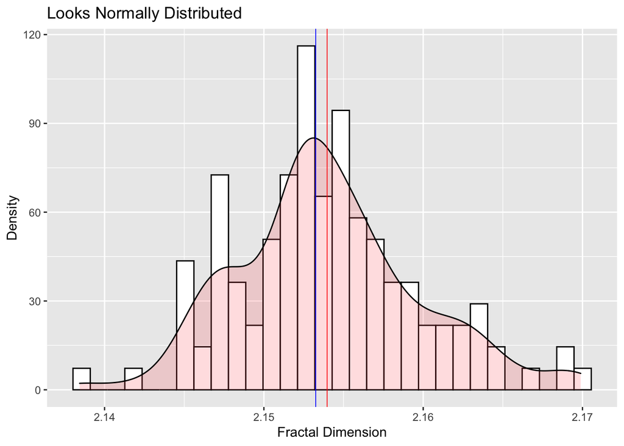

### A. Investigating categorical Hum_Dist vs continuous square root transformed Hum_dist

```r
#Models looking at disturbance gradient and if interaction between year&disturbance fit better
frac1 <- lm(frac ~ year + hum_dist, data = frac) #Hum_Dist = Categorical
frac2 <- lm(frac ~ year + sqrt.hdist.cont, data = frac)
frac3 <- lm(frac ~ year * hum_dist, data = frac)
frac4 <- lm(frac~year*sqrt.hdist.cont, data = frac)

AIC(frac1, frac2,frac3,frac4) #Top model = frac4
```

```
##       df       AIC
## frac1  8 -979.5654
## frac2  7 -981.2888
## frac3 16 -988.7298
## frac4 11 -994.8592
```

```r
summary(frac1)
```

```
##
## Call:
## lm(formula = frac ~ year + hum_dist, data = frac)
##
## Residuals:
##        Min         1Q     Median         3Q        Max
## -0.0149516 -0.0031312  0.0000223  0.0033356  0.0153579
##
## Coefficients:
##                     Estimate Std. Error  t value Pr(>|t|)
## (Intercept)        2.1587797  0.0011418 1890.723  < 2e-16 ***
## year2016a         -0.0065402  0.0014544   -4.497 1.60e-05 ***
## year2016b         -0.0072144  0.0013705   -5.264 6.26e-07 ***
## year2017          -0.0075422  0.0013270   -5.684 9.42e-08 ***
## year2019          -0.0044621  0.0013998   -3.188  0.00183 **
## hum_distVery High -0.0007638  0.0010478   -0.729  0.46745
## hum_distVery Low   0.0021504  0.0011032    1.949  0.05360 .
## ---
## Signif. codes:  0 '***' 0.001 '**' 0.01 '*' 0.05 '.' 0.1 ' ' 1
##
## Residual standard error: 0.004941 on 120 degrees of freedom
## Multiple R-squared:  0.2885, Adjusted R-squared:  0.2529
## F-statistic:  8.11 on 6 and 120 DF,  p-value: 2.305e-07
```

```r
summary(frac2)
```

```
##
## Call:
## lm(formula = frac ~ year + sqrt.hdist.cont, data = frac)
##
## Residuals:
##        Min         1Q     Median         3Q        Max
## -0.0146995 -0.0030227  0.0003089  0.0035790  0.0156100
##
## Coefficients:
##                   Estimate Std. Error  t value Pr(>|t|)
## (Intercept)      2.161e+00  1.110e-03 1946.641  < 2e-16 ***
## year2016a       -6.571e-03  1.449e-03   -4.534 1.37e-05 ***
## year2016b       -7.214e-03  1.366e-03   -5.280 5.76e-07 ***
## year2017        -7.503e-03  1.322e-03   -5.676 9.62e-08 ***
## year2019        -4.486e-03  1.395e-03   -3.216  0.00167 **
## sqrt.hdist.cont -3.831e-05  1.432e-05   -2.676  0.00848 **
## ---
## Signif. codes:  0 '***' 0.001 '**' 0.01 '*' 0.05 '.' 0.1 ' ' 1
##
## Residual standard error: 0.004926 on 121 degrees of freedom
## Multiple R-squared:  0.2869, Adjusted R-squared:  0.2575
## F-statistic: 9.739 on 5 and 121 DF,  p-value: 7.743e-08
```

```r
summary(frac3)
```

```
##
## Call:
## lm(formula = frac ~ year * hum_dist, data = frac)
##
## Residuals:
##       Min        1Q    Median        3Q       Max
## -0.015778 -0.002639 -0.000013  0.002265  0.014531
##
## Coefficients:
##                               Estimate Std. Error  t value Pr(>|t|)
## (Intercept)                  2.160e+00  1.544e-03 1398.658  < 2e-16 ***
## year2016a                   -5.912e-03  2.251e-03   -2.627 0.009830 **
## year2016b                   -7.783e-03  2.184e-03   -3.564 0.000538 ***
## year2017                    -9.515e-03  2.184e-03   -4.358 2.93e-05 ***
## year2019                    -6.673e-03  2.184e-03   -3.056 0.002805 **
## hum_distVery High           -4.945e-03  2.184e-03   -2.264 0.025472 *
## hum_distVery Low             4.065e-03  2.251e-03    1.806 0.073589 .
## year2016a:hum_distVery High  3.882e-03  3.136e-03    1.238 0.218375
## year2016b:hum_distVery High  2.747e-03  3.088e-03    0.889 0.375699
## year2017:hum_distVery High   5.309e-03  3.088e-03    1.719 0.088329 .
## year2019:hum_distVery High   8.802e-03  3.088e-03    2.850 0.005202 **
## year2016a:hum_distVery Low  -9.043e-03  3.621e-03   -2.497 0.013965 *
## year2016b:hum_distVery Low  -1.241e-03  3.183e-03   -0.390 0.697288
## year2017:hum_distVery Low    2.673e-05  3.040e-03    0.009 0.993000
## year2019:hum_distVery Low   -3.434e-03  3.321e-03   -1.034 0.303329
## ---
## Signif. codes:  0 '***' 0.001 '**' 0.01 '*' 0.05 '.' 0.1 ' ' 1
##
## Residual standard error: 0.004632 on 112 degrees of freedom
## Multiple R-squared:  0.4164, Adjusted R-squared:  0.3434
## F-statistic: 5.708 on 14 and 112 DF,  p-value: 2.99e-08
```

```r
summary(frac4)
```

```
##
## Call:
## lm(formula = frac ~ year * sqrt.hdist.cont, data = frac)
##
## Residuals:
##        Min         1Q     Median         3Q        Max
## -0.0152156 -0.0025691 -0.0001308  0.0028088  0.0150939
##
## Coefficients:
##                             Estimate Std. Error  t value Pr(>|t|)
## (Intercept)                2.164e+00  1.437e-03 1506.299  < 2e-16 ***
## year2016a                 -1.313e-02  2.358e-03   -5.569 1.66e-07 ***
## year2016b                 -9.288e-03  2.032e-03   -4.572 1.21e-05 ***
## year2017                  -1.014e-02  1.884e-03   -5.383 3.82e-07 ***
## year2019                  -1.125e-02  2.151e-03   -5.230 7.52e-07 ***
## sqrt.hdist.cont           -1.209e-04  2.928e-05   -4.130 6.84e-05 ***
## year2016a:sqrt.hdist.cont  1.573e-04  4.532e-05    3.472 0.000724 ***
## year2016b:sqrt.hdist.cont  5.431e-05  4.141e-05    1.312 0.192188
## year2017:sqrt.hdist.cont   6.701e-05  3.961e-05    1.692 0.093362 .
## year2019:sqrt.hdist.cont   1.699e-04  4.290e-05    3.961 0.000129 ***
## ---
## Signif. codes:  0 '***' 0.001 '**' 0.01 '*' 0.05 '.' 0.1 ' ' 1
##
## Residual standard error: 0.004602 on 117 degrees of freedom
## Multiple R-squared:  0.3983, Adjusted R-squared:  0.352
## F-statistic: 8.607 on 9 and 117 DF,  p-value: 8.113e-10
```

### B. Investigate region and human disturbance (cont and categorical)

```r
#Categorical human disturbance against region, then categorical interaction with year
#Models without interaction of disturbance added with different regions
frac5 <- lm(frac ~ year + hum_dist + island.side, data = frac)
frac6 <- lm(frac~ year + hum_dist + region.3, data = frac)
frac7 <- lm(frac ~ year*hum_dist + island.side, data = frac)
frac8 <- lm(frac~year*hum_dist + region.3, data = frac)

AIC(frac5, frac6, frac7, frac8) #frac7,8 best
```

```
##       df       AIC
## frac5  9 -1016.408
## frac6  9 -1016.408
## frac7 17 -1020.488
## frac8 17 -1020.488
```

```r
summary(frac5)
```

```
##
## Call:
## lm(formula = frac ~ year + hum_dist + island.side, data = frac)
##
## Residuals:
##        Min         1Q     Median         3Q        Max
## -0.0108969 -0.0030785 -0.0001278  0.0030060  0.0103392
##
## Coefficients:
##                       Estimate Std. Error  t value Pr(>|t|)
## (Intercept)          2.1582405  0.0009874 2185.697  < 2e-16 ***
## year2016a           -0.0056677  0.0012605   -4.496 1.62e-05 ***
## year2016b           -0.0072144  0.0011810   -6.108 1.31e-08 ***
## year2017            -0.0072392  0.0011445   -6.325 4.61e-09 ***
## year2019            -0.0029044  0.0012298   -2.362   0.0198 *
## hum_distVery High   -0.0007712  0.0009030   -0.854   0.3948
## hum_distVery Low    -0.0019122  0.0011365   -1.683   0.0951 .
## island.sideWindward  0.0093176  0.0014280    6.525 1.74e-09 ***
## ---
## Signif. codes:  0 '***' 0.001 '**' 0.01 '*' 0.05 '.' 0.1 ' ' 1
##
## Residual standard error: 0.004258 on 119 degrees of freedom
## Multiple R-squared:  0.476,  Adjusted R-squared:  0.4452
## F-statistic: 15.44 on 7 and 119 DF,  p-value: 2.892e-14
```

```r
summary(frac6)
```

```
##
## Call:
## lm(formula = frac ~ year + hum_dist + region.3, data = frac)
##
## Residuals:
##        Min         1Q     Median         3Q        Max
## -0.0108969 -0.0030785 -0.0001278  0.0030060  0.0103392
##
## Coefficients: (1 not defined because of singularities)
##                       Estimate Std. Error  t value Pr(>|t|)
## (Intercept)          2.1582405  0.0009874 2185.697  < 2e-16 ***
## year2016a           -0.0056677  0.0012605   -4.496 1.62e-05 ***
## year2016b           -0.0072144  0.0011810   -6.108 1.31e-08 ***
## year2017            -0.0072392  0.0011445   -6.325 4.61e-09 ***
## year2019            -0.0029044  0.0012298   -2.362   0.0198 *
## hum_distVery High   -0.0007712  0.0009030   -0.854   0.3948
## hum_distVery Low     0.0074054  0.0012460    5.943 2.85e-08 ***
## region.3South Shore -0.0093176  0.0014280   -6.525 1.74e-09 ***
## region.3Windward            NA         NA       NA       NA
## ---
## Signif. codes:  0 '***' 0.001 '**' 0.01 '*' 0.05 '.' 0.1 ' ' 1
##
## Residual standard error: 0.004258 on 119 degrees of freedom
## Multiple R-squared:  0.476,  Adjusted R-squared:  0.4452
## F-statistic: 15.44 on 7 and 119 DF,  p-value: 2.892e-14
```

```r
summary(frac7)
```

```
##
## Call:
## lm(formula = frac ~ year * hum_dist + island.side, data = frac)
##
## Residuals:
##        Min         1Q     Median         3Q        Max
## -0.0114538 -0.0024391  0.0001548  0.0022646  0.0102073
##
## Coefficients:
##                              Estimate Std. Error  t value Pr(>|t|)
## (Intercept)                  2.159638   0.001358 1590.321  < 2e-16 ***
## year2016a                   -0.005912   0.001980   -2.987  0.00347 **
## year2016b                   -0.007783   0.001920   -4.053 9.42e-05 ***
## year2017                    -0.009515   0.001920   -4.955 2.62e-06 ***
## year2019                    -0.006673   0.001920   -3.475  0.00073 ***
## hum_distVery High           -0.004945   0.001920   -2.575  0.01135 *
## hum_distVery Low            -0.001340   0.002187   -0.613  0.54133
## island.sideWindward          0.008648   0.001488    5.814 5.96e-08 ***
## year2016a:hum_distVery High  0.003882   0.002758    1.407  0.16209
## year2016b:hum_distVery High  0.002747   0.002716    1.011  0.31409
## year2017:hum_distVery High   0.005309   0.002716    1.955  0.05311 .
## year2019:hum_distVery High   0.008802   0.002716    3.241  0.00157 **
## year2016a:hum_distVery Low  -0.005800   0.003233   -1.794  0.07554 .
## year2016b:hum_distVery Low  -0.001241   0.002800   -0.443  0.65832
## year2017:hum_distVery Low    0.001108   0.002680    0.413  0.68011
## year2019:hum_distVery Low    0.001971   0.003065    0.643  0.52140
## ---
## Signif. codes:  0 '***' 0.001 '**' 0.01 '*' 0.05 '.' 0.1 ' ' 1
##
## Residual standard error: 0.004074 on 111 degrees of freedom
## Multiple R-squared:  0.5526, Adjusted R-squared:  0.4922
## F-statistic: 9.141 on 15 and 111 DF,  p-value: 1.695e-13
```

```r
summary(frac8)
```

```
##
## Call:
## lm(formula = frac ~ year * hum_dist + region.3, data = frac)
##
## Residuals:
##        Min         1Q     Median         3Q        Max
## -0.0114538 -0.0024391  0.0001548  0.0022646  0.0102073
##
## Coefficients: (1 not defined because of singularities)
##                              Estimate Std. Error  t value Pr(>|t|)
## (Intercept)                  2.159638   0.001358 1590.321  < 2e-16 ***
## year2016a                   -0.005912   0.001980   -2.987  0.00347 **
## year2016b                   -0.007783   0.001920   -4.053 9.42e-05 ***
## year2017                    -0.009515   0.001920   -4.955 2.62e-06 ***
## year2019                    -0.006673   0.001920   -3.475  0.00073 ***
## hum_distVery High           -0.004945   0.001920   -2.575  0.01135 *
## hum_distVery Low             0.007308   0.002057    3.553  0.00056 ***
## region.3South Shore         -0.008648   0.001488   -5.814 5.96e-08 ***
## region.3Windward                   NA         NA       NA       NA
## year2016a:hum_distVery High  0.003882   0.002758    1.407  0.16209
## year2016b:hum_distVery High  0.002747   0.002716    1.011  0.31409
## year2017:hum_distVery High   0.005309   0.002716    1.955  0.05311 .
## year2019:hum_distVery High   0.008802   0.002716    3.241  0.00157 **
## year2016a:hum_distVery Low  -0.005800   0.003233   -1.794  0.07554 .
## year2016b:hum_distVery Low  -0.001241   0.002800   -0.443  0.65832
## year2017:hum_distVery Low    0.001108   0.002680    0.413  0.68011
## year2019:hum_distVery Low    0.001971   0.003065    0.643  0.52140
## ---
## Signif. codes:  0 '***' 0.001 '**' 0.01 '*' 0.05 '.' 0.1 ' ' 1
##
## Residual standard error: 0.004074 on 111 degrees of freedom
## Multiple R-squared:  0.5526, Adjusted R-squared:  0.4922
## F-statistic: 9.141 on 15 and 111 DF,  p-value: 1.695e-13
```

```r
#Dom recommends not to include categorical human disturbance as it messes with the modelling process --> Stick to continuous variable
```

**The model output for the “best fitting” model using the categorical human disturbance value comes out all wierd. In talking with Dom about it and after showing her the equivalent model with the linear continuous human disturbance, she recommends not using the categorical variable as it makes “more modelling sense” to use the continuous with my data**

```r
#Continuous human disturbance against region, then Continuous disturbance interaction with year
frac9 <- lm(frac ~ year + sqrt.hdist.cont + island.side, data = frac)
frac10  <- lm(frac ~ year + sqrt.hdist.cont + region.3, data = frac)
frac11 <- lm(frac ~ year*sqrt.hdist.cont + island.side, data = frac)
frac12 <- lm(frac ~ year*sqrt.hdist.cont + region.3, data = frac)

AIC(frac9, frac10, frac11, frac12) #Frac12<Frac11 best 2 (close ~1AIC between them)
```

```
##        df       AIC
## frac9   8 -1015.550
## frac10  9 -1016.847
## frac11 12 -1019.698
## frac12 13 -1020.817
```

```r
summary(frac9)
```

```
##
## Call:
## lm(formula = frac ~ year + sqrt.hdist.cont + island.side, data = frac)
##
## Residuals:
##        Min         1Q     Median         3Q        Max
## -0.0115788 -0.0028317 -0.0000002  0.0030873  0.0104052
##
## Coefficients:
##                       Estimate Std. Error  t value Pr(>|t|)
## (Intercept)          2.157e+00  1.098e-03 1965.229  < 2e-16 ***
## year2016a           -5.693e-03  1.269e-03   -4.485 1.68e-05 ***
## year2016b           -7.214e-03  1.189e-03   -6.065 1.57e-08 ***
## year2017            -7.344e-03  1.151e-03   -6.379 3.47e-09 ***
## year2019            -3.025e-03  1.237e-03   -2.446   0.0159 *
## sqrt.hdist.cont      5.692e-06  1.429e-05    0.398   0.6911
## island.sideWindward  8.325e-03  1.322e-03    6.297 5.17e-09 ***
## ---
## Signif. codes:  0 '***' 0.001 '**' 0.01 '*' 0.05 '.' 0.1 ' ' 1
##
## Residual standard error: 0.004289 on 120 degrees of freedom
## Multiple R-squared:  0.4641, Adjusted R-squared:  0.4373
## F-statistic: 17.32 on 6 and 120 DF,  p-value: 2.364e-14
```

```r
summary(frac10)
```

```
##
## Call:
## lm(formula = frac ~ year + sqrt.hdist.cont + region.3, data = frac)
##
## Residuals:
##        Min         1Q     Median         3Q        Max
## -0.0109096 -0.0030670 -0.0001903  0.0030273  0.0103394
##
## Coefficients:
##                       Estimate Std. Error  t value Pr(>|t|)
## (Intercept)          2.159e+00  1.477e-03 1461.615  < 2e-16 ***
## year2016a           -5.664e-03  1.258e-03   -4.501 1.59e-05 ***
## year2016b           -7.214e-03  1.179e-03   -6.119 1.24e-08 ***
## year2017            -7.239e-03  1.143e-03   -6.336 4.37e-09 ***
## year2019            -2.904e-03  1.228e-03   -2.366 0.019606 *
## sqrt.hdist.cont     -2.306e-05  2.156e-05   -1.070 0.286940
## region.3South Shore -2.799e-03  1.582e-03   -1.769 0.079415 .
## region.3Windward     6.519e-03  1.661e-03    3.924 0.000146 ***
## ---
## Signif. codes:  0 '***' 0.001 '**' 0.01 '*' 0.05 '.' 0.1 ' ' 1
##
## Residual standard error: 0.004251 on 119 degrees of freedom
## Multiple R-squared:  0.4778, Adjusted R-squared:  0.4471
## F-statistic: 15.55 on 7 and 119 DF,  p-value: 2.375e-14
```

```r
summary(frac11)
```

```
##
## Call:
## lm(formula = frac ~ year * sqrt.hdist.cont + island.side, data = frac)
##
## Residuals:
##        Min         1Q     Median         3Q        Max
## -0.0122408 -0.0026146 -0.0001276  0.0026499  0.0109974
##
## Coefficients:
##                             Estimate Std. Error  t value Pr(>|t|)
## (Intercept)                2.160e+00  1.456e-03 1483.835  < 2e-16 ***
## year2016a                 -1.085e-02  2.175e-03   -4.991 2.14e-06 ***
## year2016b                 -9.288e-03  1.836e-03   -5.060 1.59e-06 ***
## year2017                  -9.670e-03  1.704e-03   -5.673 1.05e-07 ***
## year2019                  -7.804e-03  2.052e-03   -3.803  0.00023 ***
## sqrt.hdist.cont           -6.629e-05  2.845e-05   -2.330  0.02153 *
## island.sideWindward        7.071e-03  1.353e-03    5.225 7.79e-07 ***
## year2016a:sqrt.hdist.cont  1.209e-04  4.154e-05    2.911  0.00432 **
## year2016b:sqrt.hdist.cont  5.431e-05  3.742e-05    1.452  0.14930
## year2017:sqrt.hdist.cont   5.955e-05  3.582e-05    1.662  0.09913 .
## year2019:sqrt.hdist.cont   1.153e-04  4.015e-05    2.871  0.00486 **
## ---
## Signif. codes:  0 '***' 0.001 '**' 0.01 '*' 0.05 '.' 0.1 ' ' 1
##
## Residual standard error: 0.004158 on 116 degrees of freedom
## Multiple R-squared:  0.5129, Adjusted R-squared:  0.471
## F-statistic: 12.22 on 10 and 116 DF,  p-value: 3.125e-14
```

```r
summary(frac12)
```

```
##
## Call:
## lm(formula = frac ~ year * sqrt.hdist.cont + region.3, data = frac)
##
## Residuals:
##        Min         1Q     Median         3Q        Max
## -0.0114197 -0.0024672  0.0000059  0.0025738  0.0114355
##
## Coefficients:
##                             Estimate Std. Error  t value Pr(>|t|)
## (Intercept)                2.162e+00  1.715e-03 1260.414  < 2e-16 ***
## year2016a                 -1.085e-02  2.157e-03   -5.031 1.82e-06 ***
## year2016b                 -9.288e-03  1.821e-03   -5.100 1.35e-06 ***
## year2017                  -9.444e-03  1.696e-03   -5.568 1.71e-07 ***
## year2019                  -7.472e-03  2.046e-03   -3.653 0.000392 ***
## sqrt.hdist.cont           -9.110e-05  3.181e-05   -2.864 0.004975 **
## region.3South Shore       -2.611e-03  1.544e-03   -1.691 0.093521 .
## region.3Windward           5.427e-03  1.658e-03    3.274 0.001402 **
## year2016a:sqrt.hdist.cont  1.213e-04  4.121e-05    2.944 0.003922 **
## year2016b:sqrt.hdist.cont  5.431e-05  3.712e-05    1.463 0.146130
## year2017:sqrt.hdist.cont   5.597e-05  3.560e-05    1.572 0.118659
## year2019:sqrt.hdist.cont   1.100e-04  3.995e-05    2.754 0.006850 **
## ---
## Signif. codes:  0 '***' 0.001 '**' 0.01 '*' 0.05 '.' 0.1 ' ' 1
##
## Residual standard error: 0.004125 on 115 degrees of freedom
## Multiple R-squared:  0.5248, Adjusted R-squared:  0.4793
## F-statistic: 11.54 on 11 and 115 DF,  p-value: 3.045e-14
```